# Identifying Screening-Relevant Context in an OSA Study Using Clinical Note Metadata and LLM-Extracted Signals

##### 3.2.4.1 LLM Prompt Evaluation Results

The LLM prompt was evaluated using 1,735 notes from 97 patients in the training set. Patient-level recall was high across all exclusion categories from the first version of the prompt: 98.7% for clinical contraindications, 94.6% for recent procedures, and 95.2% for sleep-specific exclusions. This indicates that the model reliably identified patients who should be excluded.

A manual review of 271 notes from 15 patients (5 patients per exclusion bucket) was also done to assess whether the LLM’s explanations aligned with the context of each note. There were only two cases where the LLM’s rationale differed from the CRC’s exclusion reasons. However, both patients were still correctly excluded in the appropriate bucket.

Because all exclusion buckets exceeded the 80% recall threshold and the rationales made sense, the prompt was frozen and applied to the entire dataset (training and testing notes) to complete the multi-classification task and generate the outcome variables (prediction flags) used for downstream modeling.

### 3.3 PHASE 2 - Regression Modeling and Interpretation of Note Metadata Predictors

After Phase 1 produced note-level exclusion flags, the next step was to build the analytic dataset by performing feature engineering and preparing predictors for the regression modeling.

#### 3.3.1 Loading Required Packages

To preprocess the analytic dataset and to conduct regression modeling, the following packages are loaded:

```r
require(tidyverse) # for tidy packages needed for data cleaning
require(modelsummary) # for summary of model performance
require(DescTools) # for data cleaning
```

#### 3.3.2 Loading the De-Identified Note-Level Dataset

The de-identified LLM results created in Phase 1 were exported from Databricks as a CSV and imported as a dataframe into R. Each row represents a single clinical note with its associated metadata and LLM-derived exclusion predictions. The data was loaded as follows:

```r
notes_metadata <- read_csv('../datasets/notes_data.csv')
notes_metadata
```

| note_id | pat_id | pat_enc_csn_id | note_service_dttm | ip_note_type | note_type | specialty | encounter_type | window_bin | source | pred_clinical_contra | pred_procedural_recent | pred_sleep_specific | confidence_clinical_contra | confidence_procedural_recent | confidence_sleep_specific |
| --- | --- | --- | --- | --- | --- | --- | --- | --- | --- | --- | --- | --- | --- | --- | --- |
| Gdo7qKFXSmFFrCM3yUXq6T | 6oPzsNXAswyhX9UGeEPevC | CCqJeKDXY7UWuj27oXs4Wb | 2024-09-15 | Progress Notes | Progress Note | Internal Medicine | Medication Management | >180d | clinical_note | 0 | 0 | 0 | 0.90 | 0.90 | 0.90 |
| mXwwpFHVDMmvPmBcM8yem4 | 9Nxhf8PDA4oDzC2Dabjihu | Ey3G4PZpsttV2UvwDgZtvR | 2025-04-02 | Progress Notes | Progress Note | Neurology | Office Visit | 91–180d | clinical_note | 1 | 0 | 0 | 0.90 | 0.80 | 0.70 |
| VjLM4ZBrFm7qMgvVTmbhMq | U8TntsuusuQmGPDgdXkZn8 | LtYYDhUkFNkMHztcB7K7Wy | 2025-08-02 | Progress Notes | Progress Note | Sleep Medicine | Telemedicine | 0–30d | clinical_note | 0 | 0 | 1 | 0.90 | 0.90 | 1.00 |
| WvaStucdCWZSySbAMwf4VJ | 7QkGjnNc9nQswBBWjH92cR | Hv2CKA8MXz58kq9CiGnCQq | 2025-07-25 | Progress Notes | Progress Note | null | Reconciled Outside Data | 31–90d | clinical_note | 1 | 0 | 0 | 0.90 | 0.80 | 0.70 |
| ddSLHXk6K6yaXyfmT6bRnM | YitCgYLCQyP7dfgsKnpcQT | hBtQXikqwPpDdHpK2Cgwd6 | 2025-08-06 | Progress Notes | Progress Note | Internal Medicine | Medication Management | 91–180d | clinical_note | 0 | 0 | 0 | 0.90 | 0.90 | 0.90 |
| TtLCheArA265eNEXNST8pq | 9YBHNmcpf2AsSyv3LBWqZS | cQUgJYn6H5HF34zTsQf492 | 2025-02-09 | Progress Notes | Progress Note | Neurology | Office Visit | >180d | clinical_note | 1 | 1 | 0 | 0.90 | 0.80 | 0.00 |
| CxpoWvDQiZ2xeRZDzQ247v | XXULAL9aHLx7pdq56Tope9 | 8s3y8efPsm78wH8xfSJLWm | 2025-07-12 | Progress Notes | Progress Note | Pulmonary | Telemedicine | 31–90d | clinical_note | 1 | 0 | 0 | 0.90 | 0.80 | 0.70 |
| NGpgJvrzRYxy24v3oKeyqU | oNw9XYDpSjs3L97uR7iKqe | FjHki3V2uqp83rwd9rbWda | 2024-12-13 | Progress Notes | Progress Note | Cardiology | Office Visit | >180d | clinical_note | 1 | 0 | 0 | 0.90 | 0.80 | 0.90 |
| f9zv3zSxbLgxJSrTMYNgxP | ZPUfiUKzNm5oqMA4vJFcwD | hYN32gwZg7nTQuKZ3q6hzs | 2025-05-01 | Progress Notes | Progress Note | Pulmonary | Office Visit | 31–90d | clinical_note | 1 | 0 | 1 | 0.90 | 0.80 | 0.85 |
| LDAcR4RUiz9CVR45WH976c | fg5E4Z37iYFfztSiYkjkhf | B8EAPQn78gtakvdt86YTcb | 2024-10-01 | Op Note | null | null | Hospital Encounter | >180d | surgical_note | 0 | 0 | 0 | 0.00 | 0.00 | 0.00 |

[output cut: 2901 more lines]

#### 3.3.3 Handling Null Values and Converting Metadata Fields to Factor Type

Because Databricks exports missing character fields as the literal string ‘null’, these must be converted to proper NA values:

```r
notes_metadata <- notes_metadata %>%
  mutate(across(where(is.character), ~na_if(., "null")))
notes_metadata
```

| note_id | pat_id | pat_enc_csn_id | note_service_dttm | ip_note_type | note_type | specialty | encounter_type | window_bin | source | pred_clinical_contra | pred_procedural_recent | pred_sleep_specific | confidence_clinical_contra | confidence_procedural_recent | confidence_sleep_specific |
| --- | --- | --- | --- | --- | --- | --- | --- | --- | --- | --- | --- | --- | --- | --- | --- |
| Gdo7qKFXSmFFrCM3yUXq6T | 6oPzsNXAswyhX9UGeEPevC | CCqJeKDXY7UWuj27oXs4Wb | 2024-09-15 | Progress Notes | Progress Note | Internal Medicine | Medication Management | >180d | clinical_note | 0 | 0 | 0 | 0.90 | 0.90 | 0.90 |
| mXwwpFHVDMmvPmBcM8yem4 | 9Nxhf8PDA4oDzC2Dabjihu | Ey3G4PZpsttV2UvwDgZtvR | 2025-04-02 | Progress Notes | Progress Note | Neurology | Office Visit | 91–180d | clinical_note | 1 | 0 | 0 | 0.90 | 0.80 | 0.70 |
| VjLM4ZBrFm7qMgvVTmbhMq | U8TntsuusuQmGPDgdXkZn8 | LtYYDhUkFNkMHztcB7K7Wy | 2025-08-02 | Progress Notes | Progress Note | Sleep Medicine | Telemedicine | 0–30d | clinical_note | 0 | 0 | 1 | 0.90 | 0.90 | 1.00 |
| WvaStucdCWZSySbAMwf4VJ | 7QkGjnNc9nQswBBWjH92cR | Hv2CKA8MXz58kq9CiGnCQq | 2025-07-25 | Progress Notes | Progress Note | NA | Reconciled Outside Data | 31–90d | clinical_note | 1 | 0 | 0 | 0.90 | 0.80 | 0.70 |
| ddSLHXk6K6yaXyfmT6bRnM | YitCgYLCQyP7dfgsKnpcQT | hBtQXikqwPpDdHpK2Cgwd6 | 2025-08-06 | Progress Notes | Progress Note | Internal Medicine | Medication Management | 91–180d | clinical_note | 0 | 0 | 0 | 0.90 | 0.90 | 0.90 |
| TtLCheArA265eNEXNST8pq | 9YBHNmcpf2AsSyv3LBWqZS | cQUgJYn6H5HF34zTsQf492 | 2025-02-09 | Progress Notes | Progress Note | Neurology | Office Visit | >180d | clinical_note | 1 | 1 | 0 | 0.90 | 0.80 | 0.00 |
| CxpoWvDQiZ2xeRZDzQ247v | XXULAL9aHLx7pdq56Tope9 | 8s3y8efPsm78wH8xfSJLWm | 2025-07-12 | Progress Notes | Progress Note | Pulmonary | Telemedicine | 31–90d | clinical_note | 1 | 0 | 0 | 0.90 | 0.80 | 0.70 |
| NGpgJvrzRYxy24v3oKeyqU | oNw9XYDpSjs3L97uR7iKqe | FjHki3V2uqp83rwd9rbWda | 2024-12-13 | Progress Notes | Progress Note | Cardiology | Office Visit | >180d | clinical_note | 1 | 0 | 0 | 0.90 | 0.80 | 0.90 |
| f9zv3zSxbLgxJSrTMYNgxP | ZPUfiUKzNm5oqMA4vJFcwD | hYN32gwZg7nTQuKZ3q6hzs | 2025-05-01 | Progress Notes | Progress Note | Pulmonary | Office Visit | 31–90d | clinical_note | 1 | 0 | 1 | 0.90 | 0.80 | 0.85 |
| LDAcR4RUiz9CVR45WH976c | fg5E4Z37iYFfztSiYkjkhf | B8EAPQn78gtakvdt86YTcb | 2024-10-01 | Op Note | NA | NA | Hospital Encounter | >180d | surgical_note | 0 | 0 | 0 | 0.00 | 0.00 | 0.00 |

[output cut: 2901 more lines]

To prevent rows from being dropped during `glm()` due to missing factor levels, missing metadata was recoded as “Unknown” and the core note metadata fields were converted to factors:

```r
notes_metadata <- notes_metadata %>%
  mutate(across(c(ip_note_type, note_type, specialty,
                  encounter_type, window_bin, source),
                ~ case_when(is.na(.x) ~ 'Unknown',
                          T ~ .x))) %>% # recoding NA to unknown or keep value if not NA
  mutate(across(c(ip_note_type, note_type, specialty,
                  encounter_type, window_bin, source),
                ~ as.factor(.x))) # converting predictor variables to factors
notes_metadata
```

| note_id | pat_id | pat_enc_csn_id | note_service_dttm | ip_note_type | note_type | specialty | encounter_type | window_bin | source | pred_clinical_contra | pred_procedural_recent | pred_sleep_specific | confidence_clinical_contra | confidence_procedural_recent | confidence_sleep_specific |
| --- | --- | --- | --- | --- | --- | --- | --- | --- | --- | --- | --- | --- | --- | --- | --- |
| Gdo7qKFXSmFFrCM3yUXq6T | 6oPzsNXAswyhX9UGeEPevC | CCqJeKDXY7UWuj27oXs4Wb | 2024-09-15 | Progress Notes | Progress Note | Internal Medicine | Medication Management | >180d | clinical_note | 0 | 0 | 0 | 0.90 | 0.90 | 0.90 |
| mXwwpFHVDMmvPmBcM8yem4 | 9Nxhf8PDA4oDzC2Dabjihu | Ey3G4PZpsttV2UvwDgZtvR | 2025-04-02 | Progress Notes | Progress Note | Neurology | Office Visit | 91–180d | clinical_note | 1 | 0 | 0 | 0.90 | 0.80 | 0.70 |
| VjLM4ZBrFm7qMgvVTmbhMq | U8TntsuusuQmGPDgdXkZn8 | LtYYDhUkFNkMHztcB7K7Wy | 2025-08-02 | Progress Notes | Progress Note | Sleep Medicine | Telemedicine | 0–30d | clinical_note | 0 | 0 | 1 | 0.90 | 0.90 | 1.00 |
| WvaStucdCWZSySbAMwf4VJ | 7QkGjnNc9nQswBBWjH92cR | Hv2CKA8MXz58kq9CiGnCQq | 2025-07-25 | Progress Notes | Progress Note | Unknown | Reconciled Outside Data | 31–90d | clinical_note | 1 | 0 | 0 | 0.90 | 0.80 | 0.70 |
| ddSLHXk6K6yaXyfmT6bRnM | YitCgYLCQyP7dfgsKnpcQT | hBtQXikqwPpDdHpK2Cgwd6 | 2025-08-06 | Progress Notes | Progress Note | Internal Medicine | Medication Management | 91–180d | clinical_note | 0 | 0 | 0 | 0.90 | 0.90 | 0.90 |
| TtLCheArA265eNEXNST8pq | 9YBHNmcpf2AsSyv3LBWqZS | cQUgJYn6H5HF34zTsQf492 | 2025-02-09 | Progress Notes | Progress Note | Neurology | Office Visit | >180d | clinical_note | 1 | 1 | 0 | 0.90 | 0.80 | 0.00 |
| CxpoWvDQiZ2xeRZDzQ247v | XXULAL9aHLx7pdq56Tope9 | 8s3y8efPsm78wH8xfSJLWm | 2025-07-12 | Progress Notes | Progress Note | Pulmonary | Telemedicine | 31–90d | clinical_note | 1 | 0 | 0 | 0.90 | 0.80 | 0.70 |
| NGpgJvrzRYxy24v3oKeyqU | oNw9XYDpSjs3L97uR7iKqe | FjHki3V2uqp83rwd9rbWda | 2024-12-13 | Progress Notes | Progress Note | Cardiology | Office Visit | >180d | clinical_note | 1 | 0 | 0 | 0.90 | 0.80 | 0.90 |
| f9zv3zSxbLgxJSrTMYNgxP | ZPUfiUKzNm5oqMA4vJFcwD | hYN32gwZg7nTQuKZ3q6hzs | 2025-05-01 | Progress Notes | Progress Note | Pulmonary | Office Visit | 31–90d | clinical_note | 1 | 0 | 1 | 0.90 | 0.80 | 0.85 |
| LDAcR4RUiz9CVR45WH976c | fg5E4Z37iYFfztSiYkjkhf | B8EAPQn78gtakvdt86YTcb | 2024-10-01 | Op Note | Unknown | Unknown | Hospital Encounter | >180d | surgical_note | 0 | 0 | 0 | 0.00 | 0.00 | 0.00 |

[output cut: 2901 more lines]

#### 3.3.4 Creating New Overall Modeling Outcome

In addition to the three note-level exclusion categories (`clinical_contra`, `procedural_recent`, and `sleep_specific`) that were created in Phase 1, a new combined “overall exclusion” was created. This new variable identifies whether any of the exclusion signals (clinical, procedural, or sleep-specific) was present in a note. This new outcome allows for conducting a more general analysis of note contexts that are associated with exclusion relevant signals regardless of the category.

```r
notes_metadata <- notes_metadata %>%
  mutate(pred_overall_excl = # if at least one pred_* field is flagged set pred_overall_excl to one
           case_when(pred_clinical_contra == 1 |
                       pred_procedural_recent == 1 |
                       pred_sleep_specific == 1 ~ 1,
                     T ~ 0)) %>%
  relocate(pred_overall_excl, .after = pred_sleep_specific) # relocating field
notes_metadata
```

| note_id | pat_id | pat_enc_csn_id | note_service_dttm | ip_note_type | note_type | specialty | encounter_type | window_bin | source | pred_clinical_contra | pred_procedural_recent | pred_sleep_specific | pred_overall_excl | confidence_clinical_contra | confidence_procedural_recent | confidence_sleep_specific |
| --- | --- | --- | --- | --- | --- | --- | --- | --- | --- | --- | --- | --- | --- | --- | --- | --- |
| Gdo7qKFXSmFFrCM3yUXq6T | 6oPzsNXAswyhX9UGeEPevC | CCqJeKDXY7UWuj27oXs4Wb | 2024-09-15 | Progress Notes | Progress Note | Internal Medicine | Medication Management | >180d | clinical_note | 0 | 0 | 0 | 0 | 0.90 | 0.90 | 0.90 |
| mXwwpFHVDMmvPmBcM8yem4 | 9Nxhf8PDA4oDzC2Dabjihu | Ey3G4PZpsttV2UvwDgZtvR | 2025-04-02 | Progress Notes | Progress Note | Neurology | Office Visit | 91–180d | clinical_note | 1 | 0 | 0 | 1 | 0.90 | 0.80 | 0.70 |
| VjLM4ZBrFm7qMgvVTmbhMq | U8TntsuusuQmGPDgdXkZn8 | LtYYDhUkFNkMHztcB7K7Wy | 2025-08-02 | Progress Notes | Progress Note | Sleep Medicine | Telemedicine | 0–30d | clinical_note | 0 | 0 | 1 | 1 | 0.90 | 0.90 | 1.00 |
| WvaStucdCWZSySbAMwf4VJ | 7QkGjnNc9nQswBBWjH92cR | Hv2CKA8MXz58kq9CiGnCQq | 2025-07-25 | Progress Notes | Progress Note | Unknown | Reconciled Outside Data | 31–90d | clinical_note | 1 | 0 | 0 | 1 | 0.90 | 0.80 | 0.70 |
| ddSLHXk6K6yaXyfmT6bRnM | YitCgYLCQyP7dfgsKnpcQT | hBtQXikqwPpDdHpK2Cgwd6 | 2025-08-06 | Progress Notes | Progress Note | Internal Medicine | Medication Management | 91–180d | clinical_note | 0 | 0 | 0 | 0 | 0.90 | 0.90 | 0.90 |
| TtLCheArA265eNEXNST8pq | 9YBHNmcpf2AsSyv3LBWqZS | cQUgJYn6H5HF34zTsQf492 | 2025-02-09 | Progress Notes | Progress Note | Neurology | Office Visit | >180d | clinical_note | 1 | 1 | 0 | 1 | 0.90 | 0.80 | 0.00 |
| CxpoWvDQiZ2xeRZDzQ247v | XXULAL9aHLx7pdq56Tope9 | 8s3y8efPsm78wH8xfSJLWm | 2025-07-12 | Progress Notes | Progress Note | Pulmonary | Telemedicine | 31–90d | clinical_note | 1 | 0 | 0 | 1 | 0.90 | 0.80 | 0.70 |
| NGpgJvrzRYxy24v3oKeyqU | oNw9XYDpSjs3L97uR7iKqe | FjHki3V2uqp83rwd9rbWda | 2024-12-13 | Progress Notes | Progress Note | Cardiology | Office Visit | >180d | clinical_note | 1 | 0 | 0 | 1 | 0.90 | 0.80 | 0.90 |
| f9zv3zSxbLgxJSrTMYNgxP | ZPUfiUKzNm5oqMA4vJFcwD | hYN32gwZg7nTQuKZ3q6hzs | 2025-05-01 | Progress Notes | Progress Note | Pulmonary | Office Visit | 31–90d | clinical_note | 1 | 0 | 1 | 1 | 0.90 | 0.80 | 0.85 |
| LDAcR4RUiz9CVR45WH976c | fg5E4Z37iYFfztSiYkjkhf | B8EAPQn78gtakvdt86YTcb | 2024-10-01 | Op Note | Unknown | Unknown | Hospital Encounter | >180d | surgical_note | 0 | 0 | 0 | 0 | 0.00 | 0.00 | 0.00 |

[output cut: 2901 more lines]

#### 3.3.5 Inspecting Metadata Distributions Prior to Collapsing

Since this dataset is a relatively small sample of notes (n = 2,911 notes), I checked to see the count of notes associated with each factor level to assess how smaller sample sizes can be collapsed and joined with other levels. This was done because sparse categories can destabilize logistic regression which may lead to potential overfitting, biased estimates, and overestimating odds ratios.

```r
# looking at counts at each factor level
table(notes_metadata$ip_note_type)
```

```
    Brief Op Note Discharge Summary          ED Notes ED Provider Notes
               51                27                75                79
              H&P Interval H&P Note           Op Note         OR PostOp
               43                 8               150                10
         OR PreOp    Progress Notes           Unknown
                5              2307               156
```

```r
table(notes_metadata$note_type)
```

```
                 H&P Note             Progress Note SURGICAL PATHOLOGY REPORT
                        8                      2173                       156
                  Unknown
                      574
```

```r
table(notes_metadata$specialty)
```

```
         Allergy/Immunology              Anesthesiology
                         12                           8
                  Audiology                  Cardiology
                          3                         137
                   CARDVASC    Colon and Rectal Surgery
                          1                           5
                        CRS                 Dermatology
                          7                         100
              Endocrinology                         EOS
                         43                          13
             ER/Observation             Family Practice
                          9                         242
           Gastroenterology                     GENERAL
                         19                           3
                   Genetics                 Gerontology
                          3                          39
                         GI                  GI Surgery
                          4                          19
                        GIS                         GYN
                         14                          12
                 Gynecology         Hematology/Oncology
                          3                          16
        Infectious Diseases           Internal Medicine
                          8                         401
                  Neurology                Neurosurgery
                         81                           2
                     OB/Gyn       Occupational Medicine
                         39                           3
                       OMFS           Oncologic Surgery
                          2                           4
                   Oncology                     OPHTHAL
                        134                           1
              Ophthalmology  Oral Maxillofacial Surgery
                         43                          12
              Oral Medicine                         ORL
                          2                          10
                      ORTHO                Orthopaedics
                          9                          58
                      Other         Otorhinolaryngology
                          1                          60
```

[output cut: 15 more lines]

```
                         35                          43
                   Research                Rheumatology
                          1                          16
             Sleep Medicine              Specialty Care
                        209                          17
            Sports Medicine            Thoracic Surgery
                          4                           1
                   THORSURG          Transplant Surgery
                          6                           1
                    Unknown                     Urology
                        570                          22
                    UROLOGY                    VASCSURG
                         13                           5
           Vascular Surgery
                          1
```

```r
table(notes_metadata$encounter_type)
```

```
                            Abstract                  Allied Health Visit
                                  20                                   48
Allied Health Visit (Non-Chargeable)                          Appointment
                                  12                                    2
                     Care Management                       CCBH Scheduled
                                  45                                   22
                    CCBH Unscheduled                           Enrollment
                                  52                                    3
                 ERRONEOUS ENCOUNTER                   Hospital Encounter
                                   2                                  530
                      Infusion Visit                         Letter (Out)
                                  88                                    2
               Medication Management                              No Show
                                   8                                    2
                   No Show-No Charge                      Nurse Navigator
                                   3                                    1
                        Office Visit                          Orders Only
                                1358                                   29
                 Out of Office Visit                     Patient Outreach
                                   1                                    4
                      Post Emergency                 Post Hospitalization
                                  12                                   24
                           Procedure                      Procedure Visit
                                  23                                    1
                      Psych Abstract                Psych Care Management
                                   2                                    5
                  Psych Office Visit                      Psych Telephone
                                   3                                    3
             Reconciled Outside Data                               Refill
                                 205                                    3
                          Refill MPM            Research (Non-Chargeable)
                                   9                                    1
                  Research Encounter                    Results Follow-Up
                                   1                                    3
                    Scanned Document         Social Work (Non-Chargeable)
                                   1                                    2
                        Telemedicine                            Telephone
                                 209                                   13
                 Transitions in Care                              Unknown
                                   1                                  156
                       Virtual Visit
                                   2
```

```r
table(notes_metadata$window_bin)
```

```
  >180d   0–30d  31–90d 91–180d
   1318     346     531     716
```

```r
# Factor Collapsing (after looking at counts above)
notes_metadata <- notes_metadata %>%
  mutate(
    ip_note_type = case_when(
      ip_note_type %in% c("Brief Op Note", "Op Note", "OR PostOp", "OR PreOp") ~ "Operative Note",
      ip_note_type %in% c("H&P", "Interval H&P Note") ~ "H&P Note",
      ip_note_type %in% c("ED Notes", "ED Provider Notes") ~ "ED Note",
      ip_note_type == "Progress Notes" ~ "Progress Note",
      ip_note_type == "Discharge Summary" ~ "Discharge Summary",
      ip_note_type == "Unknown" ~ "Unknown",
      TRUE ~ ip_note_type
    ),
    ip_note_type = factor(ip_note_type),

    note_type = case_when(
      note_type == "SURGICAL PATHOLOGY REPORT" ~ "Pathology Report",
      TRUE ~ note_type
    ),

    specialty = str_trim(specialty), # removing leading and trailing white space
    specialty = if_else(is.na(specialty) | specialty == "", "Unknown", specialty),

    specialty = case_when(
      specialty %in% c("GYN", "Gynecology", "OB/Gyn") ~ "OB/Gyn",
      specialty %in% c("GI", "GIS", "Gastroenterology", "GI Surgery") ~ "Gastroenterology/GI",
      specialty %in% c("ORTHO", "Orthopaedics", "Orthopedics") ~ "Orthopedics",
      specialty %in% c("Urology", "UROLOGY") ~ "Urology",
      specialty %in% c('PMR', "Physical Medicine and Rehab") ~
        'PM&R',
      specialty %in% c('Hematology/Oncology', 'Oncology') ~ 'Heme/Onc',
      specialty %in% c("ORL", "Otorhinolaryngology") ~ "ENT",
      specialty %in% c(
        "Colon and Rectal Surgery",
        "Oral Maxillofacial Surgery",
        "Plastic Surgery",
        "PLASSURG",
        "Thoracic Surgery",
        "THORSURG",
        "Transplant Surgery",
        "VASCSURG",
        "Vascular Surgery",
        "EOS",
        "CRS"
      ) ~ "Surgery - Other",
      TRUE ~ specialty
    ),

    # if any of the factor levels have less than 10 collapse to 'Other Specialty'
    specialty = fct_lump_min(factor(specialty), min = 10, other_level = "Other Specialty"),
    specialty = factor(specialty), # making sure the variable is still a factor
    encounter_type = str_trim(encounter_type),

    encounter_type = case_when(
      encounter_type == "Office Visit" ~ "Office Visit",
      encounter_type == "Telemedicine" ~ "Telemedicine",

      encounter_type %in% c("Hospital Encounter",
                            "Post Hospitalization",
                            "Post Emergency") ~ "Hospital Encounter",

      encounter_type %in% c("Procedure", "Procedure Visit",
                            "Infusion Visit", "Medication Management",
                            "Orders Only") ~ "Procedure/Treatment",

      encounter_type == "Reconciled Outside Data" ~ "Reconciled Outside Data",

      # Administrative / communication / scheduling
      encounter_type %in% c(
        "Care Management", "Allied Health Visit", "Allied Health Visit (Non-Chargeable)",
        "Appointment", "Letter (Out)", "Telephone", "Out of Office Visit",
        "Patient Outreach", "Transitions in Care", "No Show-No Charge",
        "Psych Care Management", "Social Work (Non-Chargeable)",
        "Enrollment", "CCBH Scheduled", "CCBH Unscheduled"
      ) ~ "Ancillary Encounter",

      encounter_type %in% c("Unknown", "Research",
                            "Research Encounter", "Research (Non-Chargeable)") ~ "Other Encounter",

      TRUE ~ "Other Encounter"
    ),

    encounter_type = factor(encounter_type)
  )
notes_metadata
```

| note_id | pat_id | pat_enc_csn_id | note_service_dttm | ip_note_type | note_type | specialty | encounter_type | window_bin | source | pred_clinical_contra | pred_procedural_recent | pred_sleep_specific | pred_overall_excl | confidence_clinical_contra | confidence_procedural_recent | confidence_sleep_specific |
| --- | --- | --- | --- | --- | --- | --- | --- | --- | --- | --- | --- | --- | --- | --- | --- | --- |
| Gdo7qKFXSmFFrCM3yUXq6T | 6oPzsNXAswyhX9UGeEPevC | CCqJeKDXY7UWuj27oXs4Wb | 2024-09-15 | Progress Note | Progress Note | Internal Medicine | Procedure/Treatment | >180d | clinical_note | 0 | 0 | 0 | 0 | 0.90 | 0.90 | 0.90 |
| mXwwpFHVDMmvPmBcM8yem4 | 9Nxhf8PDA4oDzC2Dabjihu | Ey3G4PZpsttV2UvwDgZtvR | 2025-04-02 | Progress Note | Progress Note | Neurology | Office Visit | 91–180d | clinical_note | 1 | 0 | 0 | 1 | 0.90 | 0.80 | 0.70 |
| VjLM4ZBrFm7qMgvVTmbhMq | U8TntsuusuQmGPDgdXkZn8 | LtYYDhUkFNkMHztcB7K7Wy | 2025-08-02 | Progress Note | Progress Note | Sleep Medicine | Telemedicine | 0–30d | clinical_note | 0 | 0 | 1 | 1 | 0.90 | 0.90 | 1.00 |
| WvaStucdCWZSySbAMwf4VJ | 7QkGjnNc9nQswBBWjH92cR | Hv2CKA8MXz58kq9CiGnCQq | 2025-07-25 | Progress Note | Progress Note | Unknown | Reconciled Outside Data | 31–90d | clinical_note | 1 | 0 | 0 | 1 | 0.90 | 0.80 | 0.70 |
| ddSLHXk6K6yaXyfmT6bRnM | YitCgYLCQyP7dfgsKnpcQT | hBtQXikqwPpDdHpK2Cgwd6 | 2025-08-06 | Progress Note | Progress Note | Internal Medicine | Procedure/Treatment | 91–180d | clinical_note | 0 | 0 | 0 | 0 | 0.90 | 0.90 | 0.90 |
| TtLCheArA265eNEXNST8pq | 9YBHNmcpf2AsSyv3LBWqZS | cQUgJYn6H5HF34zTsQf492 | 2025-02-09 | Progress Note | Progress Note | Neurology | Office Visit | >180d | clinical_note | 1 | 1 | 0 | 1 | 0.90 | 0.80 | 0.00 |
| CxpoWvDQiZ2xeRZDzQ247v | XXULAL9aHLx7pdq56Tope9 | 8s3y8efPsm78wH8xfSJLWm | 2025-07-12 | Progress Note | Progress Note | Pulmonary | Telemedicine | 31–90d | clinical_note | 1 | 0 | 0 | 1 | 0.90 | 0.80 | 0.70 |
| NGpgJvrzRYxy24v3oKeyqU | oNw9XYDpSjs3L97uR7iKqe | FjHki3V2uqp83rwd9rbWda | 2024-12-13 | Progress Note | Progress Note | Cardiology | Office Visit | >180d | clinical_note | 1 | 0 | 0 | 1 | 0.90 | 0.80 | 0.90 |
| f9zv3zSxbLgxJSrTMYNgxP | ZPUfiUKzNm5oqMA4vJFcwD | hYN32gwZg7nTQuKZ3q6hzs | 2025-05-01 | Progress Note | Progress Note | Pulmonary | Office Visit | 31–90d | clinical_note | 1 | 0 | 1 | 1 | 0.90 | 0.80 | 0.85 |
| LDAcR4RUiz9CVR45WH976c | fg5E4Z37iYFfztSiYkjkhf | B8EAPQn78gtakvdt86YTcb | 2024-10-01 | Operative Note | Unknown | Unknown | Hospital Encounter | >180d | surgical_note | 0 | 0 | 0 | 0 | 0.00 | 0.00 | 0.00 |

[output cut: 2901 more lines]

#### 3.3.6 Harmonizing Note Type Fields

In the dataset, there are two fields that capture the note type: `ip_note_type` and `note_type`. As shown in the code below, these fields tend to overlap. To address this, I create one harmonized field called `note_type_final`. This field selects the non-Unknown value when one source is populated, collapses matching values, and assigns ‘Unknown’ when both fields are empty:

```r
# showing distinct ip_note_type and note_type
notes_metadata %>%
  distinct(ip_note_type, note_type)
```

| ip_note_type | note_type |
| --- | --- |
| Progress Note | Progress Note |
| Operative Note | Unknown |
| Progress Note | Unknown |
| ED Note | Unknown |
| H&P Note | Unknown |
| Unknown | Pathology Report |
| Discharge Summary | Unknown |
| H&P Note | H&P Note |

```r
notes_metadata <- notes_metadata %>%
  # case when below used to get the non unknown value for note_type_final field
  mutate(note_type_final =
           factor(case_when(
             # keeps not unknown ip_note_type value
             ip_note_type != 'Unknown' & note_type == 'Unknown' ~ ip_note_type,
             # keeps not unknown note_type value
             ip_note_type == "Unknown" & note_type != 'Unknown' ~ note_type,
             # assigns unknown because boths fields have an unknown value
             ip_note_type == "Unknown" & note_type == "Unknown" ~ 'Unknown',
             # collapses matching values
             ip_note_type == note_type
             ~ note_type
             ## NOTE: Conflicting cases is not addresses because based on the code above,
             ## this does not happen
             ))) %>%
  relocate(note_type_final, .after = note_type)
notes_metadata
```

| note_id | pat_id | pat_enc_csn_id | note_service_dttm | ip_note_type | note_type | note_type_final | specialty | encounter_type | window_bin | source | pred_clinical_contra | pred_procedural_recent | pred_sleep_specific | pred_overall_excl | confidence_clinical_contra | confidence_procedural_recent | confidence_sleep_specific |
| --- | --- | --- | --- | --- | --- | --- | --- | --- | --- | --- | --- | --- | --- | --- | --- | --- | --- |
| Gdo7qKFXSmFFrCM3yUXq6T | 6oPzsNXAswyhX9UGeEPevC | CCqJeKDXY7UWuj27oXs4Wb | 2024-09-15 | Progress Note | Progress Note | Progress Note | Internal Medicine | Procedure/Treatment | >180d | clinical_note | 0 | 0 | 0 | 0 | 0.90 | 0.90 | 0.90 |
| mXwwpFHVDMmvPmBcM8yem4 | 9Nxhf8PDA4oDzC2Dabjihu | Ey3G4PZpsttV2UvwDgZtvR | 2025-04-02 | Progress Note | Progress Note | Progress Note | Neurology | Office Visit | 91–180d | clinical_note | 1 | 0 | 0 | 1 | 0.90 | 0.80 | 0.70 |
| VjLM4ZBrFm7qMgvVTmbhMq | U8TntsuusuQmGPDgdXkZn8 | LtYYDhUkFNkMHztcB7K7Wy | 2025-08-02 | Progress Note | Progress Note | Progress Note | Sleep Medicine | Telemedicine | 0–30d | clinical_note | 0 | 0 | 1 | 1 | 0.90 | 0.90 | 1.00 |
| WvaStucdCWZSySbAMwf4VJ | 7QkGjnNc9nQswBBWjH92cR | Hv2CKA8MXz58kq9CiGnCQq | 2025-07-25 | Progress Note | Progress Note | Progress Note | Unknown | Reconciled Outside Data | 31–90d | clinical_note | 1 | 0 | 0 | 1 | 0.90 | 0.80 | 0.70 |
| ddSLHXk6K6yaXyfmT6bRnM | YitCgYLCQyP7dfgsKnpcQT | hBtQXikqwPpDdHpK2Cgwd6 | 2025-08-06 | Progress Note | Progress Note | Progress Note | Internal Medicine | Procedure/Treatment | 91–180d | clinical_note | 0 | 0 | 0 | 0 | 0.90 | 0.90 | 0.90 |
| TtLCheArA265eNEXNST8pq | 9YBHNmcpf2AsSyv3LBWqZS | cQUgJYn6H5HF34zTsQf492 | 2025-02-09 | Progress Note | Progress Note | Progress Note | Neurology | Office Visit | >180d | clinical_note | 1 | 1 | 0 | 1 | 0.90 | 0.80 | 0.00 |
| CxpoWvDQiZ2xeRZDzQ247v | XXULAL9aHLx7pdq56Tope9 | 8s3y8efPsm78wH8xfSJLWm | 2025-07-12 | Progress Note | Progress Note | Progress Note | Pulmonary | Telemedicine | 31–90d | clinical_note | 1 | 0 | 0 | 1 | 0.90 | 0.80 | 0.70 |
| NGpgJvrzRYxy24v3oKeyqU | oNw9XYDpSjs3L97uR7iKqe | FjHki3V2uqp83rwd9rbWda | 2024-12-13 | Progress Note | Progress Note | Progress Note | Cardiology | Office Visit | >180d | clinical_note | 1 | 0 | 0 | 1 | 0.90 | 0.80 | 0.90 |
| f9zv3zSxbLgxJSrTMYNgxP | ZPUfiUKzNm5oqMA4vJFcwD | hYN32gwZg7nTQuKZ3q6hzs | 2025-05-01 | Progress Note | Progress Note | Progress Note | Pulmonary | Office Visit | 31–90d | clinical_note | 1 | 0 | 1 | 1 | 0.90 | 0.80 | 0.85 |
| LDAcR4RUiz9CVR45WH976c | fg5E4Z37iYFfztSiYkjkhf | B8EAPQn78gtakvdt86YTcb | 2024-10-01 | Operative Note | Unknown | Operative Note | Unknown | Hospital Encounter | >180d | surgical_note | 0 | 0 | 0 | 0 | 0.00 | 0.00 | 0.00 |

[output cut: 2901 more lines]

After pre-processing and collapsing factors, I performed final quality checks of the analytic dataset before modeling by assessing the distribution of notes based on each LLM-based exclusion prediction:

```r
# looking at count for classes (exclusion present or not)
table(notes_metadata$pred_overall_excl)
```

```
   0    1
1450 1461
```

```r
table(notes_metadata$pred_clinical_contra)
```

```
   0    1
1720 1191
```

```r
table(notes_metadata$pred_procedural_recent)
```

```
   0    1
2539  372
```

```r
table(notes_metadata$pred_sleep_specific)
```

```
   0    1
2606  305
```

Because the positive class counts for `pred_procedural_recent` and `pred_sleep_specific` were small, both categories were combined into a single indicator, `pred_other_excl`. This aggregation also reflects the CRC’s real pre-screening workflow in which exclusions are grouped as ‘Medical Condition’ versus ‘Other’. ‘Medical Condition’ exclusions are represented by `pred_clinical_contra` and ‘Other’ exclusions are represented by `pred_other_excl` (the union of procedural and sleep-related exclusion buckets). Doing this will help increase statistical stability:

```r
notes_metadata <- notes_metadata %>%
  mutate(pred_other_excl = # if any of the following pred_* field is 1, pred_other_excl = 1
           case_when(pred_procedural_recent == 1 |
                       pred_sleep_specific == 1 ~ 1,
                     T ~ 0)) %>%
  relocate(pred_other_excl, .after = pred_overall_excl)
notes_metadata
```

| note_id | pat_id | pat_enc_csn_id | note_service_dttm | ip_note_type | note_type | note_type_final | specialty | encounter_type | window_bin | source | pred_clinical_contra | pred_procedural_recent | pred_sleep_specific | pred_overall_excl | pred_other_excl | confidence_clinical_contra | confidence_procedural_recent | confidence_sleep_specific |
| --- | --- | --- | --- | --- | --- | --- | --- | --- | --- | --- | --- | --- | --- | --- | --- | --- | --- | --- |
| Gdo7qKFXSmFFrCM3yUXq6T | 6oPzsNXAswyhX9UGeEPevC | CCqJeKDXY7UWuj27oXs4Wb | 2024-09-15 | Progress Note | Progress Note | Progress Note | Internal Medicine | Procedure/Treatment | >180d | clinical_note | 0 | 0 | 0 | 0 | 0 | 0.90 | 0.90 | 0.90 |
| mXwwpFHVDMmvPmBcM8yem4 | 9Nxhf8PDA4oDzC2Dabjihu | Ey3G4PZpsttV2UvwDgZtvR | 2025-04-02 | Progress Note | Progress Note | Progress Note | Neurology | Office Visit | 91–180d | clinical_note | 1 | 0 | 0 | 1 | 0 | 0.90 | 0.80 | 0.70 |
| VjLM4ZBrFm7qMgvVTmbhMq | U8TntsuusuQmGPDgdXkZn8 | LtYYDhUkFNkMHztcB7K7Wy | 2025-08-02 | Progress Note | Progress Note | Progress Note | Sleep Medicine | Telemedicine | 0–30d | clinical_note | 0 | 0 | 1 | 1 | 1 | 0.90 | 0.90 | 1.00 |
| WvaStucdCWZSySbAMwf4VJ | 7QkGjnNc9nQswBBWjH92cR | Hv2CKA8MXz58kq9CiGnCQq | 2025-07-25 | Progress Note | Progress Note | Progress Note | Unknown | Reconciled Outside Data | 31–90d | clinical_note | 1 | 0 | 0 | 1 | 0 | 0.90 | 0.80 | 0.70 |
| ddSLHXk6K6yaXyfmT6bRnM | YitCgYLCQyP7dfgsKnpcQT | hBtQXikqwPpDdHpK2Cgwd6 | 2025-08-06 | Progress Note | Progress Note | Progress Note | Internal Medicine | Procedure/Treatment | 91–180d | clinical_note | 0 | 0 | 0 | 0 | 0 | 0.90 | 0.90 | 0.90 |
| TtLCheArA265eNEXNST8pq | 9YBHNmcpf2AsSyv3LBWqZS | cQUgJYn6H5HF34zTsQf492 | 2025-02-09 | Progress Note | Progress Note | Progress Note | Neurology | Office Visit | >180d | clinical_note | 1 | 1 | 0 | 1 | 1 | 0.90 | 0.80 | 0.00 |
| CxpoWvDQiZ2xeRZDzQ247v | XXULAL9aHLx7pdq56Tope9 | 8s3y8efPsm78wH8xfSJLWm | 2025-07-12 | Progress Note | Progress Note | Progress Note | Pulmonary | Telemedicine | 31–90d | clinical_note | 1 | 0 | 0 | 1 | 0 | 0.90 | 0.80 | 0.70 |
| NGpgJvrzRYxy24v3oKeyqU | oNw9XYDpSjs3L97uR7iKqe | FjHki3V2uqp83rwd9rbWda | 2024-12-13 | Progress Note | Progress Note | Progress Note | Cardiology | Office Visit | >180d | clinical_note | 1 | 0 | 0 | 1 | 0 | 0.90 | 0.80 | 0.90 |
| f9zv3zSxbLgxJSrTMYNgxP | ZPUfiUKzNm5oqMA4vJFcwD | hYN32gwZg7nTQuKZ3q6hzs | 2025-05-01 | Progress Note | Progress Note | Progress Note | Pulmonary | Office Visit | 31–90d | clinical_note | 1 | 0 | 1 | 1 | 1 | 0.90 | 0.80 | 0.85 |
| LDAcR4RUiz9CVR45WH976c | fg5E4Z37iYFfztSiYkjkhf | B8EAPQn78gtakvdt86YTcb | 2024-10-01 | Operative Note | Unknown | Operative Note | Unknown | Hospital Encounter | >180d | surgical_note | 0 | 0 | 0 | 0 | 0 | 0.00 | 0.00 | 0.00 |

[output cut: 2901 more lines]

Below is the new distribution with the `pred_other_excl` field:

```r
table(notes_metadata$pred_other_excl)
```

```
   0    1
2270  641
```

#### 3.3.7 Building the final modeling dataset

```r
# getting only the necessary columns for the analytic dataset
model_df <- notes_metadata %>%
  select(pred_overall_excl, pred_clinical_contra,
         pred_procedural_recent, pred_sleep_specific,
         pred_other_excl,
         note_type_final,
         specialty,
         encounter_type,
         window_bin,
         source) %>%
  mutate(row = row_number()) %>%
  relocate(row, .before = pred_overall_excl)
model_df
```

| row | pred_overall_excl | pred_clinical_contra | pred_procedural_recent | pred_sleep_specific | pred_other_excl | note_type_final | specialty | encounter_type | window_bin | source |
| --- | --- | --- | --- | --- | --- | --- | --- | --- | --- | --- |
| 1 | 0 | 0 | 0 | 0 | 0 | Progress Note | Internal Medicine | Procedure/Treatment | >180d | clinical_note |
| 2 | 1 | 1 | 0 | 0 | 0 | Progress Note | Neurology | Office Visit | 91–180d | clinical_note |
| 3 | 1 | 0 | 0 | 1 | 1 | Progress Note | Sleep Medicine | Telemedicine | 0–30d | clinical_note |
| 4 | 1 | 1 | 0 | 0 | 0 | Progress Note | Unknown | Reconciled Outside Data | 31–90d | clinical_note |
| 5 | 0 | 0 | 0 | 0 | 0 | Progress Note | Internal Medicine | Procedure/Treatment | 91–180d | clinical_note |
| 6 | 1 | 1 | 1 | 0 | 1 | Progress Note | Neurology | Office Visit | >180d | clinical_note |
| 7 | 1 | 1 | 0 | 0 | 0 | Progress Note | Pulmonary | Telemedicine | 31–90d | clinical_note |
| 8 | 1 | 1 | 0 | 0 | 0 | Progress Note | Cardiology | Office Visit | >180d | clinical_note |
| 9 | 1 | 1 | 0 | 1 | 1 | Progress Note | Pulmonary | Office Visit | 31–90d | clinical_note |
| 10 | 0 | 0 | 0 | 0 | 0 | Operative Note | Unknown | Hospital Encounter | >180d | surgical_note |

[output cut: 2901 more lines]

#### 3.3.8 Modeling Strategy

To determine which note metadata features are most strongly associated with exclusion-relevant notes, multivariable logistic regression models were used. This method allows predictors to be evaluated simultaneously, which provide estimates of the direction and strength of the association between the metadata features and the binary exclusion indicators.

For this project, three separate models were fit:

1. an overall exclusion model to identify the most influential metadata features associated with any exclusion content (outcome variable: `pred_overall_excl`)
2. a clinical exclusion model to identify metadata features associated with medical contraindications (outcome: `pred_clinical_contra`)
3. an other exclusion model to identify metadata features associated with recent procedural or sleep-specific exclusions (outcome: `pred_other_excl` )

Because this project is exploratory and inferential (rather than predictive), models were fit using the full dataset to maximize statistical power and the certainty of the parameter estimates. Bootstrap resampling (1,000 samples per model) was then used to see if the direction and magnitude of the effects were stable across repeated samples.

## 4 Results

### 4.1 Descriptive Summaries

```r
# code is used to create table for cohort/note summary
require(kableExtra) # for generating pretty tables
# total counts
overall_counts <- notes_metadata %>%
  summarize(
    total_notes = n_distinct(note_id),
    total_patients = n_distinct(pat_id),
    total_encounters = n_distinct(pat_enc_csn_id),

  )

# Notes per patient
notes_per_patient <- notes_metadata %>%
  group_by(pat_id) %>%
  summarise(n_notes = n())

notes_per_patient_summary <- notes_per_patient %>%
  summarise(
    median_notes = median(n_notes),
    IQR_notes = IQR(n_notes),
    min_notes = min(n_notes),
    max_notes = max(n_notes)
  )

# Min and Max Note Dates
note_dates_min_max <- notes_metadata %>%
  mutate(min_note = min(note_service_dttm),
         max_note = max(note_service_dttm)) %>%
  distinct(min_note, max_note)

dataset_overview_table <- bind_cols(overall_counts, notes_per_patient_summary, note_dates_min_max) %>%
  mutate(note_date_range = paste0(format(min_note, "%m/%d/%Y"), ' to ', format(max_note, "%m/%d/%Y"))) %>%
  mutate(`Notes Per Patient` = paste0("Median: ", median_notes, ", (Min: ", min_notes, ", Max: ", max_notes, ")")) %>%
  select(`Total Notes` = total_notes, `Total Patients` = total_patients, `Total Encounters` = total_encounters, `Notes Per Patient`, `Note Date Range` = note_date_range)

tibble::tibble(
  `Cohort characteristic` = c(
    "Total notes",
    "Unique patients",
    "Unique encounters",
    "Notes per patient",
    "Note Date Range"
  ),
  `Overall` = c(
    dataset_overview_table$`Total Notes`,
    dataset_overview_table$`Total Patients`,
    dataset_overview_table$`Total Encounters`,
    dataset_overview_table$`Notes Per Patient`,
    dataset_overview_table$`Note Date Range`
  )
) %>% kable(
    caption = "Table 1. Study cohort and note characteristics",
    align = "l"
  ) %>%
  kable_styling(
    bootstrap_options = c("striped", "hover", "condensed"),
    full_width = FALSE
  )
```

Table 1. Study cohort and note characteristics

| Cohort characteristic | Overall |
| --- | --- |
| Total notes | 2911 |
| Unique patients | 164 |
| Unique encounters | 1957 |
| Notes per patient | Median: 11, (Min: 1, Max: 99) |
| Note Date Range | 09/02/2011 to 11/05/2025 |

```r
library(gtsummary) # for generating pretty output tables

# code below is used to get breakdown for each note metadata field
table_2_notelevelmetadata <- model_df %>%
  select(
    note_type_final,
    specialty,
    encounter_type,
    window_bin,
    source
  ) %>%
  tbl_summary(
    percent  = "column",
    missing  = "no",
    statistic = all_categorical() ~ "{n} ({p}%)" # getting count, percent of total notes
  ) %>%
  modify_header(
    label ~ "**Note-level metadata**"
  ) %>%
  modify_caption(
    "**Table 2. Distribution of notes by note-level metadata**"
  ) %>%
  bold_labels()

table_2_notelevelmetadata
```

**Table 2. Distribution of notes by note-level metadata**

| **Note-level metadata** | **N = 2,911**<sup>1</sup> |
| --- | --- |
| note_type_final |  |
| Discharge Summary | 27 (0.9%) |
| ED Note | 154 (5.3%) |
| H&P Note | 51 (1.8%) |
| Operative Note | 216 (7.4%) |
| Pathology Report | 156 (5.4%) |
| Progress Note | 2,307 (79%) |
| specialty |  |
| Allergy/Immunology | 12 (0.4%) |
| Cardiology | 137 (4.7%) |
| Dermatology | 100 (3.4%) |
| Endocrinology | 43 (1.5%) |
| ENT | 70 (2.4%) |
| Family Practice | 242 (8.3%) |
| Gastroenterology/GI | 56 (1.9%) |
| Gerontology | 39 (1.3%) |
| Heme/Onc | 150 (5.2%) |
| Internal Medicine | 401 (14%) |
| Neurology | 81 (2.8%) |
| OB/Gyn | 54 (1.9%) |
| Ophthalmology | 43 (1.5%) |
| Orthopedics | 67 (2.3%) |
| Pathology | 156 (5.4%) |
| PM&R | 42 (1.4%) |
| Psychiatry | 25 (0.9%) |
| Pulmonary | 74 (2.5%) |
| Radiation Oncology | 10 (0.3%) |
| Radiology | 10 (0.3%) |
| REI | 35 (1.2%) |
| Renal | 43 (1.5%) |
| Rheumatology | 16 (0.5%) |
| Sleep Medicine | 209 (7.2%) |
| Specialty Care | 17 (0.6%) |
| Surgery - Other | 96 (3.3%) |
| Unknown | 570 (20%) |
| Urology | 35 (1.2%) |
| Other Specialty | 78 (2.7%) |
| encounter_type |  |
| Ancillary Encounter | 215 (7.4%) |
| Hospital Encounter | 566 (19%) |
| Office Visit | 1,358 (47%) |
| Other Encounter | 209 (7.2%) |
| Procedure/Treatment | 149 (5.1%) |
| Reconciled Outside Data | 205 (7.0%) |
| Telemedicine | 209 (7.2%) |
| window_bin |  |
| >180d | 1,318 (45%) |
| 0–30d | 346 (12%) |
| 31–90d | 531 (18%) |
| 91–180d | 716 (25%) |
| source |  |
| clinical_note | 2,539 (87%) |
| path_note | 156 (5.4%) |
| surgical_note | 216 (7.4%) |

<sup>1</sup> n (%)

```r
# theming for all the visualizations in this report
theme_osa <- function(base_size = 11) {
  theme_minimal(base_size = base_size) +
    theme(
      plot.title      = element_text(face = "bold", size = 15),
      axis.title      = element_text(face = "bold"),
      axis.text.x     = element_text(angle = 45, hjust = 1, vjust = 1),
      axis.text       = element_text(color = "gray20"),
      panel.grid.major.x = element_blank(),
      panel.grid.minor   = element_blank(),
      panel.grid.major.y = element_line(color = "#E5E7EB"),
      axis.line       = element_line(color = "#111827"),
      legend.position = "top",
      legend.title    = element_text(face = "bold"),
      legend.text     = element_text(size = 12),
      # plot.margin     = margin(12, 14, 10, 14),
      panel.background = element_rect(fill = "white", color = NA)
    )
}

# color palette for graphs
osa_palette <- c(
  "#2C7FB8",  # muted blue
  "#7FCDBB",  # soft teal
  "#EDF8B1",  # pale yellow-green
  "#FEC44F",  # warm amber
  "#FC9272",  # blush coral
  "#9ECAE1",  # light slate blue
  "#A1D99B",  # mint
  "#BCBDDC"   # soft lavender
)
# expanding color palette above
osa_palette_expanded <- colorRampPalette(osa_palette)(50)
```

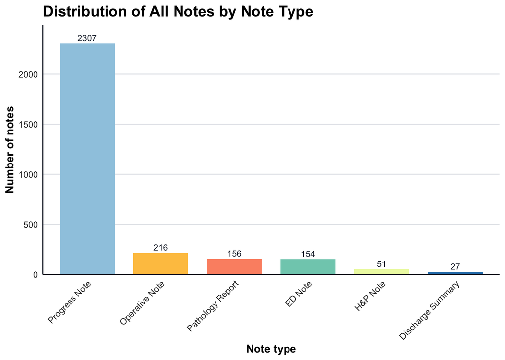

```r
# distribution of notes by note type
note_type_plot <- model_df %>%
  ggplot(aes(x = fct_infreq(note_type_final), fill = note_type_final)) +

  geom_bar(width = 0.75) +

  geom_text(
    stat = "count",
    aes(label = after_stat(count)),
    vjust = -0.4,
    size = 3,
    color = "#1F2937"   # dark slate
  ) +

  scale_fill_manual(values = osa_palette) +

  scale_y_continuous(
    expand = expansion(mult = c(0, 0.08))
  ) +

  labs(
    title = "Distribution of All Notes by Note Type",
    x = "Note type",
    y = "Number of notes",
    fill = "Note type"
  ) +

  theme_osa() +

  theme(
    legend.position = "none"   # remove legend
  )
note_type_plot
```

```r
# for presentation slides
# ggsave(
#   "../figs/note_type_plot.png",
#   plot = note_type_plot,
#   width = 5.5,   # wide
#   height = 3.0,  # short
#   dpi = 300
# )
```

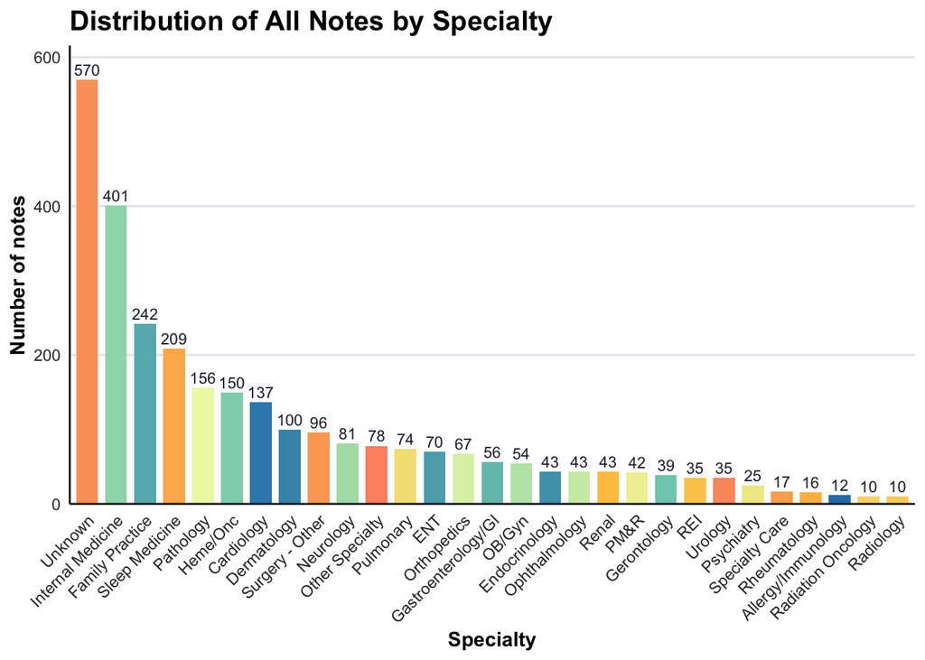

```r
# distribution of specialties
specialties_plot <- model_df %>%
  ggplot(aes(x = fct_infreq(specialty), fill = specialty)) +

  geom_bar(width = 0.75) +

  geom_text(
    stat = "count",
    aes(label = after_stat(count)),
    vjust = -0.4,
    size = 3,
    color = "#1F2937"   # dark slate
  ) +

  scale_fill_manual(values = osa_palette_expanded) +

  scale_y_continuous(
    expand = expansion(mult = c(0, 0.08))
  ) +

  labs(
    title = "Distribution of All Notes by Specialty",
    x = "Specialty",
    y = "Number of notes",
    fill = "Specialty"
  ) +

  theme_osa() +

  theme(
    legend.position = "none"   # remove legend
  )
specialties_plot
```

```r
# for presentation slides
# ggsave(
#   "../figs/specialties_plot.png",
#   plot = specialties_plot,
#   width = 5.5,   # wide
#   height = 3.0,  # short
#   dpi = 300
# )
```

**Note**

Many of the notes have an ‘Unknown’ specialty which is likely due to how the specialty field is populated during Extract-Transform-Load (ETL) into Epic Clarity. This does not indicate a problem with the analytic dataset itself.

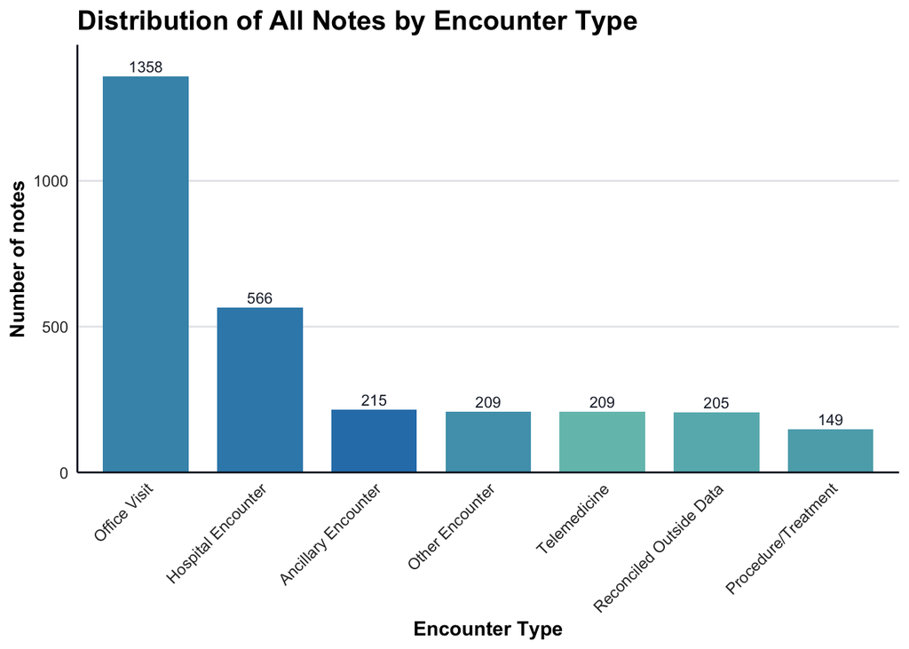

```r
# distribution of encounter type
encounter_type_plots <- model_df %>%
  ggplot(aes(x = fct_infreq(encounter_type), fill = encounter_type)) +

  geom_bar(width = 0.75) +

  geom_text(
    stat = "count",
    aes(label = after_stat(count)),
    vjust = -0.4,
    size = 3,
    color = "#1F2937"   # dark slate
  ) +

  scale_fill_manual(values = osa_palette_expanded) +

  scale_y_continuous(
    expand = expansion(mult = c(0, 0.08))
  ) +

  labs(
    title = "Distribution of All Notes by Encounter Type",
    x = "Encounter Type",
    y = "Number of notes",
    fill = "Encounter Type"
  ) +

  theme_osa() +

  theme(
    legend.position = "none"   # remove legend (redundant)
  )
encounter_type_plots
```

```r
# for presentation slides
# ggsave(
#   "../figs/encounter_type_plots.png",
#   plot = encounter_type_plots,
#   width = 5.5,   # wide
#   height = 3.0,  # short
#   dpi = 300
# )
```

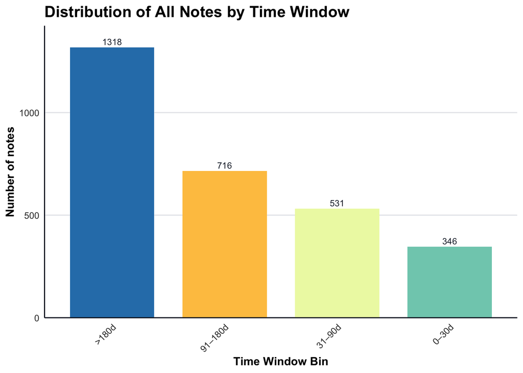

```r
# distribution of time windows
time_windows_plot <- model_df %>%
  ggplot(aes(x = fct_infreq(window_bin), fill = window_bin)) +

  geom_bar(width = 0.75) +

  geom_text(
    stat = "count",
    aes(label = after_stat(count)),
    vjust = -0.4,
    size = 3,
    color = "#1F2937"   # dark slate
  ) +

  scale_fill_manual(values = osa_palette) +

  scale_y_continuous(
    expand = expansion(mult = c(0, 0.08))
  ) +

  labs(
    title = "Distribution of All Notes by Time Window",
    x = "Time Window Bin",
    y = "Number of notes",
    fill = "Time Window Bin"
  ) +

  theme_osa() +

  theme(
    legend.position = "none"   # remove legend (redundant)
  )
time_windows_plot
```

```r
# for presentation slides
# ggsave(
#   "../figs/time_windows_plot.png",
#   plot = time_windows_plot,
#   width = 5.5,   # wide
#   height = 3.0,  # short
#   dpi = 300
# )
```

A total of 2,911 de-identified notes for 164 patients between September 2011 through November 2025 were included. As shown in the tables and figures above, the data was highly imbalanced across the different note-level metadata categories, reflecting real-world documentation patterns and nuances. Most notes were progress notes (79%), and nearly half of all notes occurred more than 180 days prior to pre-screening. Notes originated from over 20 different specialties with approximately 20% coming from unknown specialties due to limitations in data capture in the Epic Clarity database.

### 4.2 Regression Modeling

#### 4.2.1 Overall Model (All Exclusions)

```r
# reminder of the distribution --> pretty even distribution of notes with and without LLM-derived exclusion signals
table(model_df$pred_overall_excl)
```

```
   0    1
1450 1461
```

```r
# glm for overall exclusions model
overall.fit <- glm(pred_overall_excl ~ note_type_final + specialty +
                     encounter_type + window_bin,
                  data = model_df,
                  family = binomial())
summary(overall.fit) # getting summary stats for model
```

```
Call:
glm(formula = pred_overall_excl ~ note_type_final + specialty +
    encounter_type + window_bin, family = binomial(), data = model_df)

Deviance Residuals:
    Min       1Q   Median       3Q      Max
-2.6729  -0.8630   0.2048   0.8609   3.1515

Coefficients: (1 not defined because of singularities)
                                      Estimate Std. Error z value Pr(>|z|)
(Intercept)                            -0.7575     1.2193  -0.621  0.53441
note_type_finalED Note                 -4.1052     1.0427  -3.937 8.25e-05 ***
note_type_finalH&P Note                -2.3155     1.0835  -2.137  0.03260 *
note_type_finalOperative Note          -4.1938     1.0564  -3.970 7.19e-05 ***
note_type_finalPathology Report        -0.7815     1.2601  -0.620  0.53512
note_type_finalProgress Note           -2.2496     1.0338  -2.176  0.02955 *
specialtyCardiology                     2.1025     0.6495   3.237  0.00121 **
specialtyDermatology                    0.5160     0.6409   0.805  0.42080
specialtyEndocrinology                  0.5926     0.6872   0.862  0.38848
specialtyENT                            1.1458     0.6607   1.734  0.08285 .
specialtyFamily Practice               -0.4518     0.6240  -0.724  0.46905
specialtyGastroenterology/GI            1.0171     0.6779   1.500  0.13351
specialtyGerontology                    1.1187     0.6980   1.603  0.10901
specialtyHeme/Onc                       2.0356     0.6665   3.054  0.00226 **
specialtyInternal Medicine              0.2977     0.6163   0.483  0.62902
specialtyNeurology                      2.1436     0.6777   3.163  0.00156 **
specialtyOB/Gyn                         0.2239     0.6798   0.329  0.74193
specialtyOphthalmology                  1.1261     0.6934   1.624  0.10434
specialtyOrthopedics                   -0.6242     0.6721  -0.929  0.35304
specialtyPathology                          NA         NA      NA       NA
specialtyPM&R                           1.7694     0.7110   2.488  0.01283 *
specialtyPsychiatry                     1.5164     0.7831   1.936  0.05283 .
specialtyPulmonary                      1.0867     0.6570   1.654  0.09812 .
specialtyRadiation Oncology             0.8886     0.9487   0.937  0.34892
specialtyRadiology                     -1.2125     0.9764  -1.242  0.21432
specialtyREI                           -1.0219     0.9720  -1.051  0.29313
specialtyRenal                          2.9709     0.7546   3.937 8.25e-05 ***
specialtyRheumatology                   0.7432     0.8085   0.919  0.35803
specialtySleep Medicine                 1.6539     0.6419   2.577  0.00998 **
specialtySpecialty Care                 1.0754     1.2561   0.856  0.39191
```

[output cut: 8 more lines]

```
encounter_typeReconciled Outside Data   2.0585     0.3749   5.491 4.00e-08 ***
encounter_typeTelemedicine              1.8150     0.2711   6.694 2.17e-11 ***
window_bin0–30d                         1.4351     0.1573   9.125  < 2e-16 ***
window_bin31–90d                        0.3445     0.1272   2.708  0.00677 **
window_bin91–180d                       0.4635     0.1137   4.078 4.55e-05 ***
---
Signif. codes:  0 '***' 0.001 '**' 0.01 '*' 0.05 '.' 0.1 ' ' 1

(Dispersion parameter for binomial family taken to be 1)

    Null deviance: 4035.5  on 2910  degrees of freedom
Residual deviance: 3197.3  on 2869  degrees of freedom
AIC: 3281.3

Number of Fisher Scoring iterations: 5
```

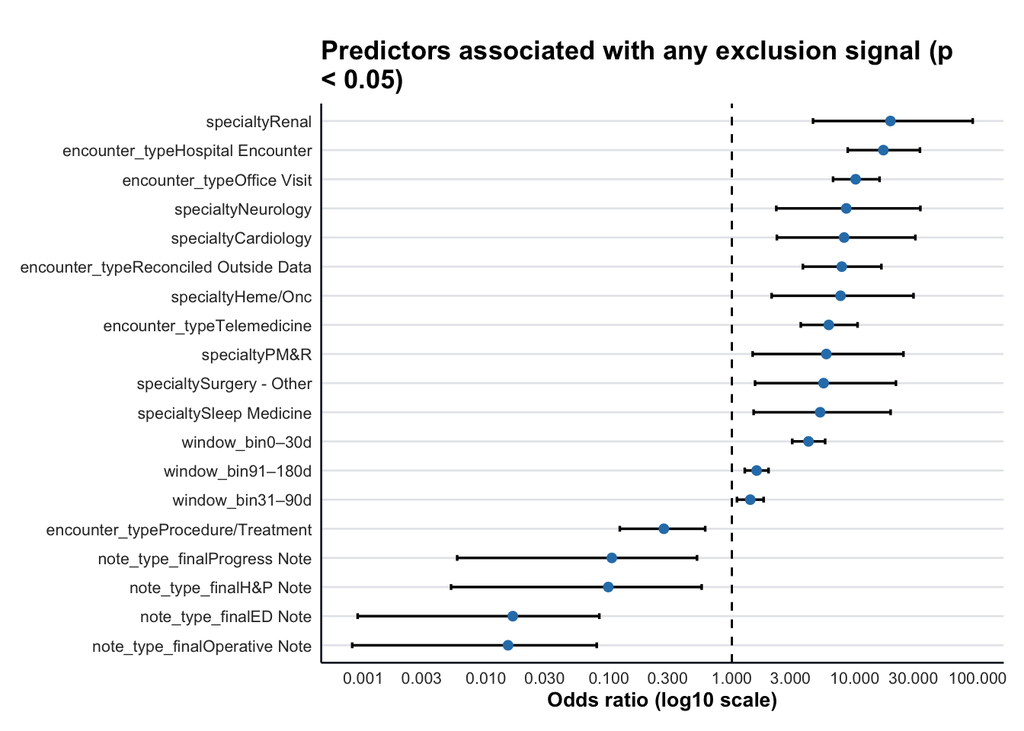

```r
# creating forest dot plot for overall exclusions model
coef_pvalues <-
  # extracting summary data from above
  as.data.frame(summary(overall.fit)$coefficients) %>%
  arrange(`Pr(>|z|)`) %>%
  filter(`Pr(>|z|)` < 0.05) %>% # only graphing results where p-value < 0.05
  rownames_to_column("term") %>%
  rename(estimate = Estimate,
         standard_error = `Std. Error`,
         z_value = `z value`,
         p_value = `Pr(>|z|)`)

or_ci <-
  # getting only the odds ratio and confidence intervals
  exp(cbind(OR = coef(overall.fit), CI = confint(overall.fit))) %>%
  as.data.frame() %>%
  rownames_to_column("term") %>%
  rename(odds_ratio = OR,
         ci_min = `2.5 %`,
         ci_max = `97.5 %`)

glm_overall <- coef_pvalues %>%
  # joining p-values with OR and CI
  inner_join(or_ci, by='term') %>%
  filter(
    term != "(Intercept)", # filtering out inercept so that it doens't get included in the graph
    !is.na(odds_ratio), # filtering only to odds rations that are not NA
    p_value < 0.05 # filtering only to results with p-value < 0.05
  )

overall_model_odds_plot <- glm_overall %>%
  # reordering terms based on odds ratios (for graphs)
  mutate(term = fct_reorder(term, odds_ratio)) %>%
  ggplot(aes(x = term, y = odds_ratio)) +
  geom_errorbar(
    aes(ymin = ci_min, ymax = ci_max), # creating confidence intervals
    width = 0.2,
    size  = 0.6
  ) +
  geom_point(size = 1.8, color = osa_palette[1]) +
  geom_hline(yintercept = 1, linetype = "dashed") +
  # making the axis into log base-10 so that it's more readaible
  scale_y_log10(breaks =scales::log_breaks(n = 10), # adjusting ticks
                labels = scales::label_number()) + # added this because of wide confidence intervals
  coord_flip() +
  labs(
    x = NULL,
    y = "Odds ratio (log10 scale)",
    title = str_wrap(
    "Predictors associated with any exclusion signal (p < 0.05)",
    width = 50) # need to do this because the entire title does not fit on one line
  ) +
  theme_osa(base_size = 10) +
  theme(
    legend.position = "none",
    axis.text.x = element_text(angle = 0, hjust = 0.5),
    axis.title.x = element_text(face = "bold"),
    plot.title = element_text(size = 13, face = "bold"),
    plot.margin = margin(t = 20, r = 10, b = 10, l = 10)
  )
overall_model_odds_plot
```

```r
# table view of of odds ratio, 95% CI, p_value < 0.05
glm_overall %>%
  mutate(across(c(p_value, estimate, standard_error, odds_ratio, ci_min, ci_max))) %>%
  select(term, p_value, odds_ratio, ci_min, ci_max) %>%
  mutate(`95% CI` =
           paste0("(", ci_min, "-", ci_max, ")")) %>%
  distinct(term, p_value, odds_ratio, `95% CI`)
```

| term | p_value | odds_ratio | 95% CI |
| --- | --- | --- | --- |
| encounter_typeOffice Visit | 1.399500e-25 | 10.16031030 | (6.6558512546189-15.9031802394504) |
| window_bin0–30d | 7.157735e-20 | 4.20010777 | (3.09747446213955-5.74059926110063) |
| encounter_typeHospital Encounter | 1.724848e-16 | 17.09400827 | (8.76418404866712-33.8920829620856) |
| encounter_typeTelemedicine | 2.165317e-11 | 6.14104495 | (3.63415524882484-10.5354940031923) |
| encounter_typeReconciled Outside Data | 4.000437e-08 | 7.83432738 | (3.78028105064735-16.4583403760883) |
| window_bin91–180d | 4.548717e-05 | 1.58964923 | (1.27272012992496-1.98750315617357) |
| note_type_finalOperative Note | 7.191286e-05 | 0.01508822 | (0.000814137403606315-0.07947612010535) |
| note_type_finalED Note | 8.249519e-05 | 0.01648661 | (0.000901593600944359-0.0834021084913586) |
| specialtyRenal | 8.252574e-05 | 19.50974092 | (4.57352331248252-91.1261440570547) |
| specialtyCardiology | 1.208019e-03 | 8.18696166 | (2.32251480494433-31.0988545689192) |

[output cut: 9 more lines]

#### 4.2.2 Clinical Contraindications Model

```r
# reminder of the distribution --> 40/66  distribution of notes with and without LLM-derived exclusion signals.
table(model_df$pred_clinical_contra)
```

```
   0    1
1720 1191
```

Since the distribution of notes with and without exclusions are imbalanced (41% vs 59%) with more notes not having clinical contraindications, inverse-frequency weighting was applied to prevent the model from favoring the majority class (notes without exclusions) for predictions. Through Inverse class weighting, the minority class (notes with exclusions) gets a larger weight:

```r
# getting sum of counts for majority and minority class
majority_0 <- sum(model_df$pred_clinical_contra == 0)
minority_1 <- sum(model_df$pred_clinical_contra == 1)

# assigning larger weight to minority exclusion class
model_df_clinical <- model_df %>%
  mutate(class_weight = ifelse(pred_clinical_contra == 1, majority_0 / minority_1, minority_1 / majority_0))

# checking class imbalance correction with weighting
aggregate(class_weight ~ pred_clinical_contra, data = model_df_clinical, mean)
```

| pred_clinical_contra | class_weight |
| --- | --- |
| 0 | 0.6924419 |
| 1 | 1.4441646 |

```r
with(model_df_clinical, tapply(class_weight, pred_clinical_contra, sum))
```

```
   0    1
1191 1720
```

```r
# fitting glm
clinical.fit <- glm(pred_clinical_contra ~ note_type_final + specialty +
                     encounter_type + window_bin,
                  data = model_df_clinical,
                  family = binomial(),
    weights = class_weight) # applying the weights to logistic regression
summary(clinical.fit) # getting summary of model
```

```
Call:
glm(formula = pred_clinical_contra ~ note_type_final + specialty +
    encounter_type + window_bin, family = binomial(), data = model_df_clinical,
    weights = class_weight)

Deviance Residuals:
    Min       1Q   Median       3Q      Max
-2.0466  -1.0002  -0.3801   0.9040   4.1893

Coefficients: (1 not defined because of singularities)
                                       Estimate Std. Error z value Pr(>|z|)
(Intercept)                            -1.18828    0.86399  -1.375  0.16903
note_type_finalED Note                 -2.43175    0.59642  -4.077 4.56e-05 ***
note_type_finalH&P Note                -1.33670    0.64763  -2.064  0.03902 *
note_type_finalOperative Note          -2.86589    0.62646  -4.575 4.77e-06 ***
note_type_finalPathology Report         0.07973    0.91643   0.087  0.93067
note_type_finalProgress Note           -0.92994    0.58365  -1.593  0.11109
specialtyCardiology                     1.90864    0.63927   2.986  0.00283 **
specialtyDermatology                   -0.08083    0.62533  -0.129  0.89715
specialtyEndocrinology                  0.59266    0.67411   0.879  0.37931
specialtyENT                            0.35335    0.64163   0.551  0.58183
specialtyFamily Practice               -0.66159    0.60555  -1.093  0.27459
specialtyGastroenterology/GI            0.05990    0.66519   0.090  0.92825
specialtyGerontology                    0.43374    0.68028   0.638  0.52374
specialtyHeme/Onc                       1.99131    0.67124   2.967  0.00301 **
specialtyInternal Medicine             -0.27133    0.59907  -0.453  0.65061
specialtyNeurology                      1.50690    0.65955   2.285  0.02233 *
specialtyOB/Gyn                        -0.17065    0.66577  -0.256  0.79771
specialtyOphthalmology                  0.65193    0.67755   0.962  0.33596
specialtyOrthopedics                   -0.78810    0.65030  -1.212  0.22555
specialtyPathology                           NA         NA      NA       NA
specialtyPM&R                           1.30853    0.69953   1.871  0.06140 .
specialtyPsychiatry                     1.77190    0.75418   2.349  0.01880 *
specialtyPulmonary                      0.66221    0.63973   1.035  0.30060
specialtyRadiation Oncology             0.90613    0.95543   0.948  0.34293
specialtyRadiology                     -0.90967    0.93145  -0.977  0.32876
specialtyREI                           -1.81614    1.07295  -1.693  0.09052 .
specialtyRenal                          2.64812    0.75599   3.503  0.00046 ***
specialtyRheumatology                   0.30813    0.79296   0.389  0.69759
specialtySleep Medicine                 0.54651    0.62041   0.881  0.37837
```

[output cut: 9 more lines]

```
encounter_typeReconciled Outside Data   2.16498    0.38945   5.559 2.71e-08 ***
encounter_typeTelemedicine              1.87703    0.28781   6.522 6.95e-11 ***
window_bin0–30d                         0.14095    0.14462   0.975  0.32975
window_bin31–90d                        0.12906    0.12803   1.008  0.31344
window_bin91–180d                       0.18202    0.11485   1.585  0.11301
---
Signif. codes:  0 '***' 0.001 '**' 0.01 '*' 0.05 '.' 0.1 ' ' 1

(Dispersion parameter for binomial family taken to be 1)

    Null deviance: 3938.8  on 2910  degrees of freedom
Residual deviance: 3233.0  on 2869  degrees of freedom
AIC: 3628.8

Number of Fisher Scoring iterations: 13
```

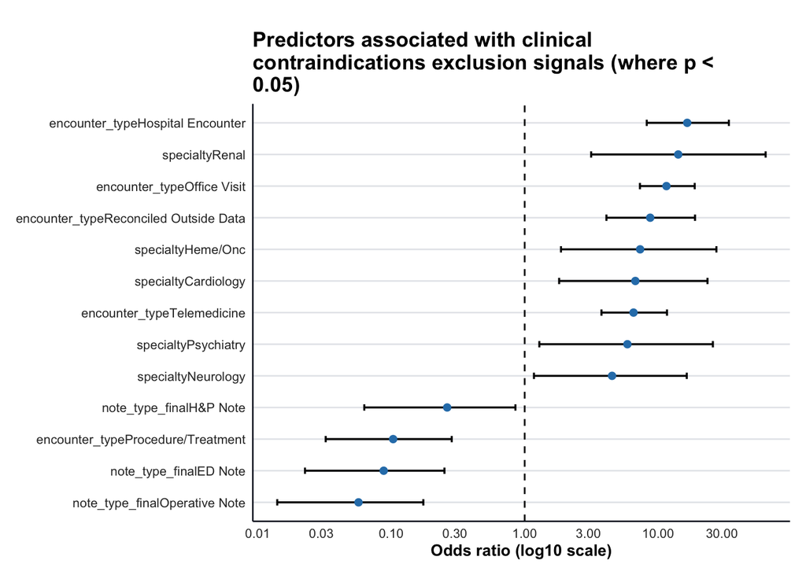

```r
coef_pvalues_clinical <-
  # getting coef results
  summary(clinical.fit)$coefficients %>%
  as.data.frame() %>%
  # getting only results with p < 0.05
  arrange(`Pr(>|z|)`) %>% filter(`Pr(>|z|)` < 0.05) %>%
  # making the title of the first column 'terms'
  rownames_to_column("term") %>%
  rename(estimate = Estimate,
         standard_error = `Std. Error`,
         z_value = `z value`,
         p_value = `Pr(>|z|)`)

or_ci_clinical <-
  # getting odds ratios
  exp(cbind(OR = coef(clinical.fit), CI = confint(clinical.fit))) %>%
  as.data.frame() %>%
  # making the title of the first column 'terms'
  rownames_to_column("term") %>%
  rename(odds_ratio = OR,
         ci_min = `2.5 %`,
         ci_max = `97.5 %`)

glm_model_clinical <- coef_pvalues_clinical %>%
  # joining OR and CI
  inner_join(or_ci_clinical, by='term') %>%
  filter(
    term != "(Intercept)", # filter out intercept
    !is.na(odds_ratio), # filtering out NA
    p_value < 0.05 # filtering out large p-values
  )

glm_model_clinical %>%
  mutate(term = fct_reorder(term, odds_ratio)) %>% # reording by odds ratio column
  ggplot(aes(x = term, y = odds_ratio)) +
  geom_errorbar(
    aes(ymin = ci_min, ymax = ci_max), # creating error bars
    width = 0.2,
    size  = 0.6
  ) +
  geom_point(size = 1.8, color = osa_palette[1]) +
  geom_hline(yintercept = 1, linetype = "dashed") +
  # making the axis into log base-10 so that it's more readaible
  scale_y_log10(breaks =scales::log_breaks(n = 10), # adjusting ticks
                labels = scales::label_number()) + # added this because of wide confidence intervals
  coord_flip()  +
  labs(
    x = NULL,
    y = "Odds ratio (log10 scale)",
    title = str_wrap("Predictors associated with clinical contraindications exclusion signals (where p < 0.05)", width = 50
  )) + # need to do this because the entire title does not fit on one line
  theme_osa(base_size = 10) + # adjusting the size of the font for terms
  theme(
    legend.position = "none",
    axis.text.x = element_text(angle = 0, hjust = 0.5),
    axis.title.x = element_text(face = "bold"),
    plot.title = element_text(size = 13, face = "bold"),
    plot.margin = margin(t = 20, r = 10, b = 10, l = 10) # plot margins
  )
```

```r
# table view of of odds ratio, 95% CI, p_value < 0.05
glm_model_clinical %>%
  mutate(across(c(estimate, standard_error, odds_ratio, ci_min, ci_max), ~round(.x, digits = 2))) %>%
  select(term, p_value, odds_ratio, ci_min, ci_max) %>%
  mutate(`95% CI` =
           paste0("(", ci_min, "-", ci_max, ")")) %>%
  distinct(term, p_value, odds_ratio, `95% CI`)
```

| term | p_value | odds_ratio | 95% CI |
| --- | --- | --- | --- |
| encounter_typeOffice Visit | 2.665161e-24 | 11.53 | (7.3-18.77) |
| encounter_typeHospital Encounter | 7.909267e-15 | 16.50 | (8.21-33.85) |
| encounter_typeTelemedicine | 6.945104e-11 | 6.53 | (3.76-11.64) |
| encounter_typeReconciled Outside Data | 2.711804e-08 | 8.71 | (4.09-18.88) |
| note_type_finalOperative Note | 4.768011e-06 | 0.06 | (0.01-0.17) |
| encounter_typeProcedure/Treatment | 3.517422e-05 | 0.10 | (0.03-0.28) |
| note_type_finalED Note | 4.557432e-05 | 0.09 | (0.02-0.25) |
| specialtyRenal | 4.603124e-04 | 14.13 | (3.15-63.81) |
| specialtyCardiology | 2.829578e-03 | 6.74 | (1.81-23.41) |
| specialtyHeme/Onc | 3.011134e-03 | 7.33 | (1.87-27.3) |

[output cut: 3 more lines]

#### 4.2.3 Other (Procedural & Recent Events, Sleep-Specific) Model

```r
table(model_df$pred_other_excl) # reminder of the distribution --> very unevenly distributed
```

```
   0    1
2270  641
```

Because the distribution of notes without and with exclusions are also imbalanced (78%/22%) with more notes not having procedural & recent events and sleep-related exclusions, inverse-frequency weighting was applied to this model also:

```r
# getting sum for majority and minority classes
majority_0_other <- sum(model_df$pred_other_excl == 0)
minority_1_other <- sum(model_df$pred_other_excl == 1)

# assigning larger weight to minority exclusion class
model_df_other <- model_df %>%
  mutate(class_weight = ifelse(pred_other_excl == 1, majority_0_other / minority_1_other, minority_1_other / majority_0_other))

# checking class imbalance correction with weighting
aggregate(class_weight ~ pred_other_excl, data = model_df_other, mean)
```

| pred_other_excl | class_weight |
| --- | --- |
| 0 | 0.2823789 |
| 1 | 3.5413417 |

```r
with(model_df_other, tapply(class_weight, pred_other_excl, sum))
```

```
   0    1
 641 2270
```

```r
# fitting glm
other.fit <- glm(pred_other_excl ~ note_type_final + specialty +
                     encounter_type + window_bin,
                  data = model_df_other,
                  family = binomial(),
    weights = class_weight) # applying the weights to logistic regression
summary(other.fit) # getting summary of model
```

```
Call:
glm(formula = pred_other_excl ~ note_type_final + specialty +
    encounter_type + window_bin, family = binomial(), data = model_df_other,
    weights = class_weight)

Deviance Residuals:
    Min       1Q   Median       3Q      Max
-1.7574  -0.9319  -0.6388  -0.2904   3.1912

Coefficients: (1 not defined because of singularities)
                                       Estimate Std. Error z value Pr(>|z|)
(Intercept)                            -1.33067    0.94292  -1.411 0.158180
note_type_finalED Note                 -1.54525    0.57939  -2.667 0.007652 **
note_type_finalH&P Note                 0.33961    0.67795   0.501 0.616416
note_type_finalOperative Note          -1.82648    0.62258  -2.934 0.003349 **
note_type_finalPathology Report        -1.70056    1.04179  -1.632 0.102608
note_type_finalProgress Note            0.08026    0.55780   0.144 0.885589
specialtyCardiology                    -0.47040    0.75314  -0.625 0.532245
specialtyDermatology                    0.66267    0.75842   0.874 0.382252
specialtyEndocrinology                 -2.20452    0.89753  -2.456 0.014041 *
specialtyENT                            0.69871    0.78000   0.896 0.370371
specialtyFamily Practice               -0.57527    0.73710  -0.780 0.435122
specialtyGastroenterology/GI            1.22596    0.81030   1.513 0.130289
specialtyGerontology                    0.77104    0.82078   0.939 0.347522
specialtyHeme/Onc                      -0.62928    0.76278  -0.825 0.409379
specialtyInternal Medicine              0.16703    0.72840   0.229 0.818625
specialtyNeurology                      0.91557    0.76950   1.190 0.234113
specialtyOB/Gyn                        -0.58044    0.81167  -0.715 0.474535
specialtyOphthalmology                  0.18502    0.81318   0.228 0.820018
specialtyOrthopedics                   -1.18696    0.80382  -1.477 0.139769
specialtyPathology                           NA         NA      NA       NA
specialtyPM&R                           2.40091    0.85651   2.803 0.005061 **
specialtyPsychiatry                   -16.56603  413.68548  -0.040 0.968057
specialtyPulmonary                      0.14436    0.77317   0.187 0.851883
specialtyRadiation Oncology           -15.61428  688.43528  -0.023 0.981905
specialtyRadiology                     -0.92018    1.13604  -0.810 0.417947
specialtyREI                            0.02212    0.90662   0.024 0.980532
specialtyRenal                          0.34217    0.82221   0.416 0.677296
specialtyRheumatology                  -0.33950    0.95907  -0.354 0.723347
specialtySleep Medicine                 1.08954    0.76016   1.433 0.151769
```

[output cut: 9 more lines]

```
encounter_typeReconciled Outside Data   1.12524    0.45984   2.447 0.014403 *
encounter_typeTelemedicine              1.66673    0.31297   5.326 1.01e-07 ***
window_bin0–30d                         2.43062    0.19044  12.763  < 2e-16 ***
window_bin31–90d                        0.51126    0.14567   3.510 0.000449 ***
window_bin91–180d                       0.59928    0.13300   4.506 6.61e-06 ***
---
Signif. codes:  0 '***' 0.001 '**' 0.01 '*' 0.05 '.' 0.1 ' ' 1

(Dispersion parameter for binomial family taken to be 1)

    Null deviance: 3069.1  on 2910  degrees of freedom
Residual deviance: 2441.7  on 2869  degrees of freedom
AIC: 1136.4

Number of Fisher Scoring iterations: 14
```

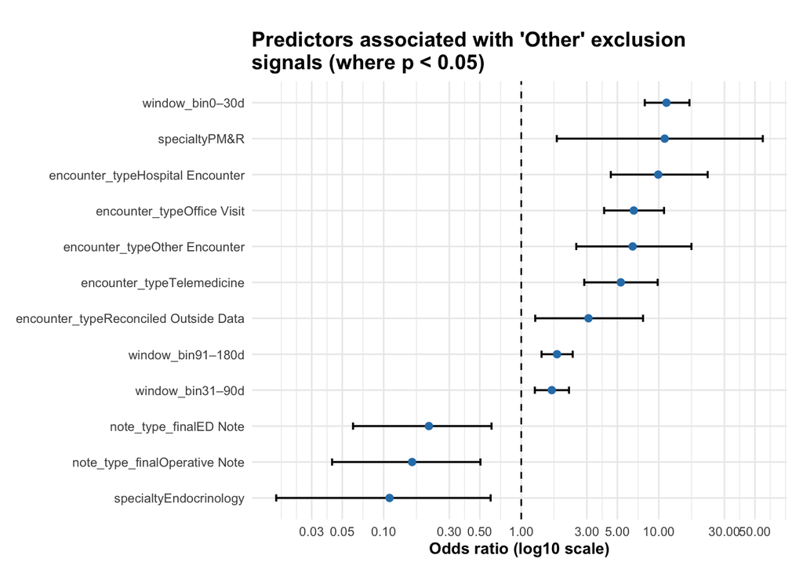

```r
# creating dot forest graph for other exclusions model
# all the same code as the previous models
coef_pvalues_other <- summary(other.fit)$coefficients %>%
  as.data.frame() %>%
  arrange(`Pr(>|z|)`) %>% filter(`Pr(>|z|)` < 0.05) %>% rownames_to_column("term") %>%
  rename(estimate = Estimate,
         standard_error = `Std. Error`,
         z_value = `z value`,
         p_value = `Pr(>|z|)`)

or_ci_other <- exp(cbind(OR = coef(other.fit), CI = confint(other.fit))) %>%
  as.data.frame() %>%
  rownames_to_column("term") %>%
  rename(odds_ratio = OR,
         ci_min = `2.5 %`,
         ci_max = `97.5 %`)

glm_model_other <- coef_pvalues_other %>%
  inner_join(or_ci_other, by='term') %>%
  filter(
    term != "(Intercept)",
    !is.na(odds_ratio),
    p_value < 0.05
  )

glm_model_other %>%
  mutate(term = fct_reorder(term, odds_ratio)) %>%
  ggplot(aes(x = term, y = odds_ratio)) +
  geom_errorbar(
    aes(ymin = ci_min, ymax = ci_max),
    width = 0.2,
    size  = 0.6
  ) +
  geom_point(size = 1.8, color = osa_palette[1]) +
  geom_hline(yintercept = 1, linetype = "dashed") +
  # making the axis into log base-10 so that it's more readaible
  scale_y_log10(breaks =scales::log_breaks(n = 10), # adjusting ticks
                labels = scales::label_number()) + # added this because of wide confidence intervals
  coord_flip() +
  labs(
    x = NULL,
    y = "Odds ratio (log10 scale)",
    title = str_wrap("Predictors associated with 'Other' exclusion signals (where p < 0.05)",
                     width = 45)
  ) +
  theme_minimal(base_size = 10) + # adjusting terms font size
   theme(
    legend.position = "none",
    axis.text.x = element_text(angle = 0, hjust = 0.5),
    axis.title.x = element_text(face = "bold"),
    plot.title = element_text(size = 13, face = "bold"),
    plot.margin = margin(t = 20, r = 10, b = 10, l = 10) # padding the graph
  )
```

```r
# table view of of odds ratio, 95% CI, p_value < 0.05
glm_model_other %>%
  mutate(across(c(estimate, standard_error, odds_ratio, ci_min, ci_max), ~round(.x, digits = 2))) %>%
  select(term, p_value, odds_ratio, ci_min, ci_max) %>%
  mutate(`95% CI` =
           paste0("(", ci_min, "-", ci_max, ")")) %>%
  distinct(term, p_value, odds_ratio, `95% CI`)
```

| term | p_value | odds_ratio | 95% CI |
| --- | --- | --- | --- |
| window_bin0–30d | 2.627719e-37 | 11.37 | (7.91-16.7) |
| encounter_typeOffice Visit | 1.609399e-13 | 6.58 | (4-10.91) |
| encounter_typeHospital Encounter | 2.783164e-08 | 9.90 | (4.48-22.66) |
| encounter_typeTelemedicine | 1.006455e-07 | 5.29 | (2.87-9.81) |
| window_bin91–180d | 6.614782e-06 | 1.82 | (1.4-2.37) |
| encounter_typeOther Encounter | 1.391773e-04 | 6.45 | (2.51-17.27) |
| window_bin31–90d | 4.487747e-04 | 1.67 | (1.26-2.22) |
| note_type_finalOperative Note | 3.349280e-03 | 0.16 | (0.04-0.51) |
| specialtyPM&R | 5.060687e-03 | 11.03 | (1.81-57) |
| note_type_finalED Note | 7.652334e-03 | 0.21 | (0.06-0.61) |

[output cut: 2 more lines]

#### 4.2.4 Model Interpretations

##### 4.2.4.1 Overall Exclusion Model

Encounter type and temporal proximity to screening were the strongest predictors of exclusion-relevant context. Hospital encounters had very high odds (Odds Ratio (OR)=17.1, Confidence Interval (CI)=8.8-33.9, p-value<0.05) and office visits were also strongly associated (OR=10.2, CI=6.7-16.0, p-value<0.05). Notes written within 0-30 days of pre-screening had nearly four times higher odds (OR=4.20, CI=3.1-5.7, p-value<0.05). Several specialties (e.g., Renal, Neurology, Cardiology, Hematology/Oncology, Sleep Medicine, and Physical Medicine and Rehabilitation (PM&R)) also showed higher odds (all ORs > 5) but confidence intervals were wider because of sparse note counts. Note type contributed the least with several note types having odds ratios below 1 and wide confidence intervals. Overall, exclusion information is most strongly associated with encounter type and recency.

##### 4.2.4.2 Clinical Contraindications Model

For clinical contraindications, encounter type and specialty were the main drivers. Office, Hospital, telemedicine, and reconciled outside data encounters were associated with higher odds of exclusion content (all ORs > 6). However, procedure/treatment encounters were unlikely to contain clinical contraindication signals (OR=0.10, CI=0.03-0.3, p-value<0.05). Renal, Cardiology, Hematology/Oncology, Psychiatry, and Neurology were statistically significant specialties, but with wide confidence intervals due to sparse notes (e.g. Renal OR=14.1, CI=3.2-63.8, p-value<0.05). Recency was not significant in this model which is consistent with chronic conditions remaining relevant regardless of when the note was written. Finally, note types effects were smaller. Emergency Department (ED), operative, and History and Physical (H&P) notes still had lower odds of containing exclusion-relevant content (e.g. Operative Note OR=0.06, CI=0.01-0.2, p-value<0.05). Additionally progress notes was no longer a statistically significant predictor (p-value = 0.1).

##### 4.2.4.3 Procedural and Sleep Related (‘Other’) Model

For recent procedures and sleep-specific exclusions, encounter type and temporal proximity to pre-screening were again the stronger predictors. Hospital encounters had high odds (OR=9.9, CI=4.5-22.7, p-value<0.05) and notes within 0-30 days from pre-screening had the highest odds of containing exclusion-related information (OR=11.4, CI=7.9-16.7, p-value<0.05). At the same time, other time bins were statistically significant but with smaller effect sizes (e.g. 31-90 days OR=1.67, CI=1.3-2.2, p-value<0..05). Specialty effects were limited with PM&R as positive and endocrinology as negative and with very wide confidence intervals for both predictor terms. Finally, note types remained a weak predictor (e.g. Operative Note OR=0.2, CI=0.04-0.5, p-value<0.05). This model reinforces that recent notes in specific encounter settings and temporal recency is the main source of procedural and sleep-specific exclusion signals.

### 4.3 Stability Analysis (Bootstrap Resampling)

Bootstrap resampling (1,000 times pre model) was used to assess how stable the effects were through repeating sampling.

#### 4.3.1 Overall

```r
library(boot) # library to conduct boostrap resampling
```

```r
# function for overall bootstrap
boot_overall <- function(data, indices) {
  # d = resampled dataset
  # indices is generated automatically by the boot() function
  d <- data[indices, ]

  # model
  model <- glm(pred_overall_excl ~ note_type_final + specialty +
                     encounter_type + window_bin,
                  data = d,
                  family = binomial())

  # summary statistics of the model
  return(coef(model))
}
```

```r
# setting the seed to get the same results every time
set.seed(123)

# applying function to get bootstrap results
boot_results <- boot(
  data = model_df, # main dataframe
  statistic = boot_overall,
  R = 1000 # 1000 iterations
)
```

```r
# getting bootstrap results
boot_results
```

```
ORDINARY NONPARAMETRIC BOOTSTRAP


Call:
boot(data = model_df, statistic = boot_overall, R = 1000)


Bootstrap Statistics :
       original        bias    std. error
t1*  -0.7575125  4.069188e+00   6.3941640
t2*  -4.1052069 -4.331992e+00   6.2279365
t3*  -2.3154699 -4.307074e+00   6.2496650
t4*  -4.1938410 -4.350115e+00   6.2189349
t5*  -0.7815064 -4.088896e+00   6.3959613
t6*  -2.2495755 -4.310475e+00   6.2167888
t7*   2.1025428  2.122272e-01   1.3923849
t8*   0.5159638  1.777975e-01   1.3884728
t9*   0.5925956  1.803568e-01   1.3992610
t10*  1.1458280  1.781167e-01   1.4018436
t11* -0.4517635  1.680871e-01   1.3838080
t12*  1.0170794  2.063068e-01   1.3969388
t13*  1.1187018  1.902502e-01   1.4311286
t14*  2.0355738  2.240146e-01   1.3951452
t15*  0.2977323  1.784832e-01   1.3726574
t16*  2.1436438  2.132982e-01   1.3977491
t17*  0.2238558  1.639115e-01   1.4056246
t18*  1.1261480  1.986858e-01   1.4274131
t19* -0.6242256  1.647545e-01   1.3960138
t21*  1.7693716  1.933155e-01   1.4170303
t22*  1.5163902  1.583992e-01   1.5455323
t23*  1.0866632  1.839504e-01   1.4090069
t24*  0.8886148 -7.684546e-02   2.8110764
t25* -1.2125041 -6.684255e-01   3.6782608
t26* -1.0219015 -1.618687e+00   4.8538111
t27*  2.9709139  2.462529e-01   1.4599888
t28*  0.7431642  2.099488e-01   1.5136354
t29*  1.6539133  2.046190e-01   1.3928598
t30*  1.0754359 -3.873735e+00   6.2575712
t31*  1.7181239  2.088036e-01   1.3945877
t32*  1.1179774  1.964396e-01   1.3908867
t33*  1.1471158  1.871907e-01   1.4248037
t34*  0.9726819  1.939221e-01   1.4017242
t35*  2.8387280  6.781927e-02   0.3488325
t36*  2.3184890  6.214677e-02   0.2354111
t37*  0.5581704  1.419730e-02   0.4048417
t38* -1.2746620 -4.718402e-02   0.5022834
t39*  2.0585150  4.943395e-02   0.3753737
t40*  1.8149949  5.107784e-02   0.2882069
t41*  1.4351102  3.420002e-02   0.1674030
t42*  0.3445260  4.503521e-05   0.1321337
t43*  0.4635134 -2.551002e-05   0.1099431
WARNING: All values of t20* are NA
```

```r
boot_df <- as.data.frame(boot_results$t) # coefficients from every bootstrap iteration (rows = resamples, columns = ter

coef_names <- names(coef(overall.fit)) # getting the term names for the overall.fit model
colnames(boot_df) <- coef_names # using the terms from the overall.fit model as the column names for the coefficient results

summary_overall_boot_results <- boot_df %>%
  # pivoting longer to create a dataframe of col1 = feature, log odds
  # dataframe contains all the iteractions
  pivot_longer(everything(), names_to = "term", values_to = "log_odds") %>%
  group_by(term) %>%
  # grouping by model term to get summary statistics of bootstrapping
  summarise(
    median_log_odds = median(log_odds, na.rm = TRUE), # median log odds
    # directional stability
    posneg_sign_pct = mean(sign(log_odds) ==
                             sign(median(median_log_odds, na.rm = TRUE))) * 100,
    median_OR = exp(median_log_odds), # median
    IQR_low = exp(quantile(log_odds, 0.25, na.rm = TRUE)), # IQR low from all iterations
    IQR_high = exp(quantile(log_odds, 0.75, na.rm = TRUE)) # IQR high from all iterations
  ) %>%
  arrange(desc(posneg_sign_pct))

summary_overall_boot_results
```

| term | median_log_odds | posneg_sign_pct | median_OR | IQR_low | IQR_high |
| --- | --- | --- | --- | --- | --- |
| encounter_typeHospital Encounter | 2.8811439 | 100.0 | 17.83466230 | 1.451046e+01 | 2.313154e+01 |
| encounter_typeOffice Visit | 2.3610962 | 100.0 | 10.60256791 | 9.123925e+00 | 1.256839e+01 |
| encounter_typeReconciled Outside Data | 2.0979890 | 100.0 | 8.14976397 | 6.265832e+00 | 1.062868e+01 |
| encounter_typeTelemedicine | 1.8646276 | 100.0 | 6.45353225 | 5.321888e+00 | 7.816139e+00 |
| note_type_finalED Note | -4.2088538 | 100.0 | 0.01486339 | 8.357432e-08 | 2.636833e-02 |
| note_type_finalOperative Note | -4.3287713 | 100.0 | 0.01318374 | 7.794549e-08 | 2.340238e-02 |
| note_type_finalProgress Note | -2.3107678 | 100.0 | 0.09918506 | 5.383360e-07 | 1.680886e-01 |
| specialtyRenal | 3.0642585 | 100.0 | 21.41857456 | 1.286387e+01 | 4.006159e+01 |
| window_bin0–30d | 1.4698471 | 100.0 | 4.34857006 | 3.866333e+00 | 4.839669e+00 |
| window_bin91–180d | 0.4616512 | 100.0 | 1.58669179 | 1.479988e+00 | 1.714539e+00 |

[output cut: 33 more lines]

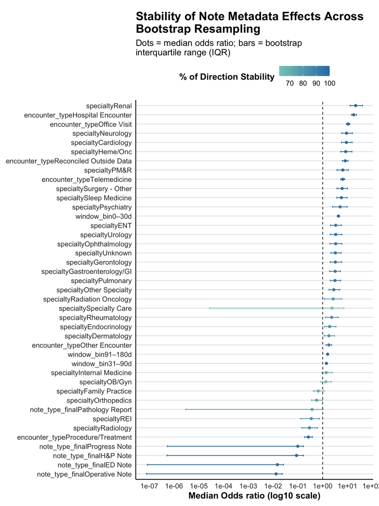

```r
summary_overall_boot_results %>%
  # specialtyPathology was removed because it did not have valid coefficient estimates due to
  # collinearity
  filter(!term %in% c("specialtyPathology", "(Intercept)")) %>%
  mutate(term = fct_reorder(term, median_OR)) %>% # ordering by median OR
  # coloring points by directional stability
  ggplot(aes(x = term, y = median_OR, color = posneg_sign_pct)) +
  geom_errorbar(
    aes(ymin = IQR_low, ymax = IQR_high), # error bars
    width = 0.2, # size of vertical ends of error bars
    size  = 0.6 # thickness of error bars
  ) +
  geom_point(size = 1.8) + # point size
  geom_hline(yintercept = 1, linetype = "dashed") +
  # making the axis into log base-10 so that it's more readaible
  scale_y_log10(breaks =scales::log_breaks(n = 10)) + # adjusting ticks
  coord_flip() +
  labs(
    x = NULL,
    y = "Median Odds ratio (log10 scale)",
    title = str_wrap("Stability of Note Metadata Effects Across Bootstrap Resampling",
                     width = 50), # so that the title fits in the entire image
    subtitle = str_wrap(
      "Dots = median odds ratio; bars = bootstrap interquartile range (IQR)",
      width = 50),
    color = "% of Direction Stability"
  ) +
  theme_osa(base_size = 15) + # adjusting size of terms font size
   theme(
    axis.text.x = element_text(angle = 0, hjust = 0.5),
    axis.title.x = element_text(face = "bold"),
    plot.title = element_text(size = 20, face = "bold"),
    plot.margin = margin(t = 20, r = 10, b = 10, l = 10)
  ) +
  # gradient for directional stability scale
  scale_color_gradientn(
    colors = c(
      "#7FCDBB",
      "#2C7FB8"
    )
  )
```

```r
# getting count of terms with directional stability >= 90%
summary_overall_boot_results %>%
  filter(!term %in% c('(Intercept)', 'specialtyPathology')) %>%
  filter(posneg_sign_pct > 90.0) %>% summarize(count = n())
```

| count |
| --- |
| 29 |

```r
# getting count of terms with directional stability <= 50%
summary_overall_boot_results %>%
  filter(!term %in% c('(Intercept)', 'specialtyPathology')) %>%
  filter(posneg_sign_pct <= 50.0) %>%
  summarize(count = n())
```

| count |
| --- |
| 0 |

#### 4.3.2 Clinical Contraindications

```r
# same code from overall model
boot_clinical <- function(data, indices) {
  d <- data[indices, ]

  # adjustment for overall model --> changing outcome variable to pred_clinical_contra
  model <- glm(pred_clinical_contra ~ note_type_final + specialty +
                     encounter_type + window_bin,
                  data = d,
                  family = binomial())

  return(coef(model))
}
```

```r
# same code from overall model
set.seed(123)

boot_results_clinical <- boot(
  data = model_df,
  statistic = boot_clinical, # using the bootstrapping function for the clinical model
  R = 1000 # 1000 iterations
)
```

```r
# getting results for boostrapping for clinical contraindications model
boot_results_clinical
```

```
ORDINARY NONPARAMETRIC BOOTSTRAP


Call:
boot(data = model_df, statistic = boot_clinical, R = 1000)


Bootstrap Statistics :
        original       bias    std. error
t1*  -1.94832583 -0.105288249   1.8031812
t2*  -2.46638120 -0.154409278   1.1360686
t3*  -1.36222363 -0.145640333   1.1652019
t4*  -2.79038612 -0.174806377   1.1582944
t5*   0.04711018  0.070011491   1.8235373
t6*  -0.84172870 -0.134952929   1.1246673
t7*   1.86172739  0.199133392   1.3731967
t8*  -0.10558206  0.166883520   1.3753626
t9*   0.59939101  0.177194919   1.3816680
t10*  0.31847093  0.158208903   1.3853117
t11* -0.67111262  0.167041520   1.3708924
t12*  0.07962799  0.186522624   1.3852593
t13*  0.41016643  0.168355547   1.3996855
t14*  2.25259150  0.220775456   1.4022795
t15* -0.27033892  0.169640191   1.3590799
t16*  1.52640429  0.186357909   1.3784898
t17* -0.20178698  0.147909361   1.4011699
t18*  0.64695039  0.185741380   1.4034332
t19* -0.78092984  0.158458113   1.3921516
t21*  1.20477689  0.180116219   1.4077583
t22*  1.55690964  0.177575166   1.4731011
t23*  0.62603497  0.167851814   1.3932224
t24*  0.75510527 -0.094422202   2.9107204
t25* -0.96206037 -0.709056519   3.7852151
t26* -1.89764121 -3.994917705   6.4215369
t27*  2.63108814  0.238628644   1.4441453
t28*  0.32818183  0.195557528   1.4434449
t29*  0.55573445  0.186402529   1.3711654
t30* -9.26982879 -0.283078497   2.2459281
t31*  0.74399470  0.175935925   1.3758104
t32*  0.84400975  0.190481365   1.3748553
t33*  0.64322878  0.172716622   1.4063730
t34*  0.76302967  0.183014412   1.3922295
t35*  2.80820123  0.074085518   0.3724285
t36*  2.39493045  0.069440467   0.2645391
t37*  0.79352539  0.029941960   0.4026525
t38* -2.58047950 -0.316634339   2.0058193
t39*  2.02039168  0.052645842   0.3947522
t40*  1.80462385  0.055591738   0.3090463
t41*  0.10662705  0.003469640   0.1486555
t42*  0.12468612 -0.001476144   0.1292633
t43*  0.18043516 -0.005228482   0.1106173
WARNING: All values of t20* are NA
```

```r
# same code as in other model to get table of boostrapping results
boot_df_clinical <- as.data.frame(boot_results_clinical$t)

coef_names <- names(coef(clinical.fit))
colnames(boot_df_clinical) <- coef_names

summary_clinical_boot_results <- boot_df_clinical %>%
  pivot_longer(everything(), names_to = "term", values_to = "log_odds") %>%
  group_by(term) %>%
  summarise(
    median_log_odds = median(log_odds, na.rm = TRUE),
    posneg_sign_pct = mean(sign(log_odds) ==
                             sign(median(median_log_odds, na.rm = TRUE))) * 100,
    median_OR = exp(median_log_odds),
    IQR_low = exp(quantile(log_odds, 0.25, na.rm = TRUE)),
    IQR_high = exp(quantile(log_odds, 0.75, na.rm = TRUE))
  ) %>%
  arrange(desc(posneg_sign_pct))

# outputting dataframe of boostrap results
summary_clinical_boot_results
```

| term | median_log_odds | posneg_sign_pct | median_OR | IQR_low | IQR_high |
| --- | --- | --- | --- | --- | --- |
| encounter_typeHospital Encounter | 2.88067506 | 100.0 | 1.782630e+01 | 1.402367e+01 | 2.282503e+01 |
| encounter_typeOffice Visit | 2.44712312 | 100.0 | 1.155506e+01 | 9.729137e+00 | 1.400512e+01 |
| encounter_typeProcedure/Treatment | -2.56931841 | 100.0 | 7.658773e-02 | 4.010513e-02 | 1.194504e-01 |
| encounter_typeReconciled Outside Data | 2.07764357 | 100.0 | 7.985629e+00 | 6.032365e+00 | 1.027805e+01 |
| encounter_typeTelemedicine | 1.85270742 | 100.0 | 6.377062e+00 | 5.199839e+00 | 7.849017e+00 |
| note_type_finalED Note | -2.48522787 | 100.0 | 8.330657e-02 | 5.216101e-02 | 1.247145e-01 |
| note_type_finalOperative Note | -2.82871571 | 100.0 | 5.908869e-02 | 3.638393e-02 | 8.832135e-02 |
| specialtyRenal | 2.76989220 | 99.9 | 1.595691e+01 | 9.361447e+00 | 2.726296e+01 |
| specialtyHeme/Onc | 2.35950547 | 99.8 | 1.058572e+01 | 6.725181e+00 | 1.786178e+01 |
| specialtyCardiology | 1.96923303 | 99.3 | 7.165179e+00 | 4.553168e+00 | 1.139426e+01 |

[output cut: 33 more lines]

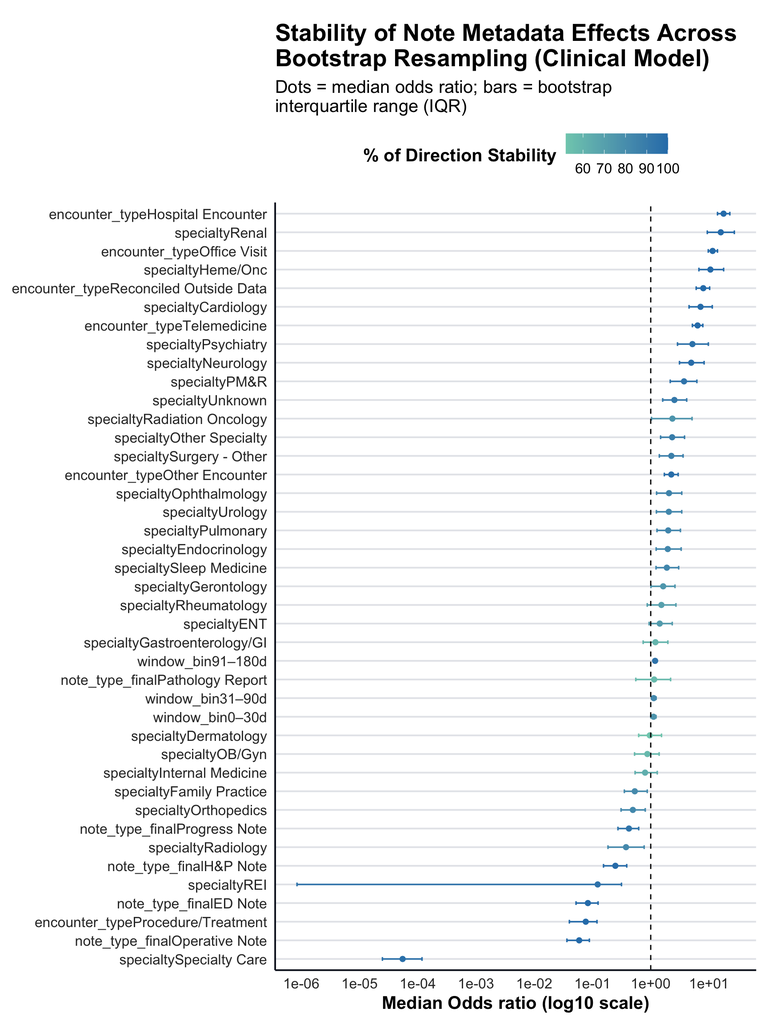

```r
# same code as in overall model to get dot forest plot for clinical contraindications model bootstrapping
summary_clinical_boot_results %>%
  filter(!term %in% c("specialtyPathology", "(Intercept)")) %>%
  mutate(term = fct_reorder(term, median_OR)) %>%
  ggplot(aes(x = term, y = median_OR, color = posneg_sign_pct)) +
  geom_errorbar(
    # IQR = range of log odds from bootstrapp iterations
    aes(ymin = IQR_low, ymax = IQR_high),
    width = 0.2,
    size  = 0.6
  ) +
  geom_point(size = 1.8) +
  geom_hline(yintercept = 1, linetype = "dashed") +
  scale_y_log10(breaks =scales::log_breaks(n = 10)) +
  coord_flip() +
  labs(
    x = NULL,
    y = "Median Odds ratio (log10 scale)",
    title = str_wrap(
      "Stability of Note Metadata Effects Across Bootstrap Resampling (Clinical Model)",
      width = 50),
    subtitle = str_wrap(
      "Dots = median odds ratio; bars = bootstrap interquartile range (IQR)",
      width = 50),
    color = "% of Direction Stability"
  ) +
  theme_osa(base_size = 15) +
  theme(
    axis.text.x = element_text(angle = 0, hjust = 0.5),
    axis.title.x = element_text(face = "bold"),
    plot.title = element_text(size = 20, face = "bold"),
    plot.margin = margin(t = 20, r = 10, b = 10, l = 10)
  )  +
  scale_color_gradientn(
    colors = c(
      "#7FCDBB",
      "#2C7FB8"
    )
  )
```

```r
# same code as for overall model
summary_clinical_boot_results %>%
  filter(!term %in% c('(Intercept)', 'specialtyPathology')) %>%
  filter(posneg_sign_pct > 90.0) %>% summarize(count = n()) # terms with >= 90% stability
```

| count |
| --- |
| 20 |

```r
summary_clinical_boot_results %>%
  filter(!term %in% c('(Intercept)', 'specialtyPathology')) %>%
  filter(posneg_sign_pct <= 50.0) %>% summarize(count = n()) # terms with <= 50% stability
```

| count |
| --- |
| 0 |

#### 4.3.3 Procedural and Sleep-Related (‘Other’)

```r
# same code as for overall and clinical contraindications model
boot_other <- function(data, indices) {
  d <- data[indices, ]

  # changes --> outcome variable is now pred_other_excl
  model <- glm(pred_other_excl ~ note_type_final + specialty +
                     encounter_type + window_bin,
                  data = d,
                  family = binomial())

  return(coef(model))
}
```

```r
# same code as overall and clinical contraindications model to run boostrapping
set.seed(123)

boot_results_other <- boot(
  data = model_df,
  statistic = boot_other, # using boot_other function instead to get results
  R = 1000 # 1000 iterations
)
```

```r
# outputting other exclusions bootstrapping results
boot_results_other
```

```
ORDINARY NONPARAMETRIC BOOTSTRAP


Call:
boot(data = model_df, statistic = boot_other, R = 1000)


Bootstrap Statistics :
          original        bias    std. error
t1*  -4.047963e+00 -2.0431059532   5.2545089
t2*  -1.622654e+00 -0.0161077934   0.5031735
t3*   9.983153e-02 -0.0083045304   0.5523257
t4*  -1.699400e+00 -0.0386419218   0.5305829
t5*  -4.740674e-01  2.0300837828   5.3297407
t6*   1.323042e-01  0.0068527371   0.4573739
t7*  -7.312549e-02  1.9521360653   5.2484429
t8*   1.139061e+00  1.9659546862   5.2447643
t9*  -1.736789e+00  0.0732896170   7.0656133
t10*  1.184878e+00  1.9665540311   5.2332946
t11* -1.689469e-01  1.9538081326   5.2374201
t12*  1.397324e+00  1.9758187862   5.2413903
t13*  1.170582e+00  1.9275051960   5.2658932
t14* -1.000529e-01  1.9584579981   5.2372000
t15*  5.047137e-01  1.9688611868   5.2269886
t16*  1.345466e+00  1.9782243516   5.2403792
t17* -9.757460e-02  1.7249122040   5.5116587
t18*  3.014264e-01  1.8847705534   5.2068994
t19* -5.713808e-01  1.8965285871   5.2333668
t21*  2.157984e+00  1.9785982614   5.2365695
t22* -1.474571e+01  2.0007825811   5.2066965
t23*  5.494226e-01  1.9668957273   5.2357600
t24* -1.407501e+01  2.0357258917   5.1956332
t25* -9.434253e-01 -0.0722752045   7.3982947
t26* -2.058110e-02  0.0475805298   7.1919332
t27*  6.460752e-01  1.8873136155   5.2929675
t28* -5.098957e-02 -0.0542821822   7.3579469
t29*  1.262656e+00  1.9725849574   5.2294531
t30*  4.038298e-04 -2.5504452834   8.4037063
t31*  1.391674e+00  1.9776548419   5.2477521
t32*  9.818626e-01  1.9813778903   5.2434509
t33*  5.946929e-01  1.8638601596   5.2937716
t34* -3.338687e-01  1.8433467972   5.3747282
t35*  2.562068e+00  0.0628862157   0.4256889
t36*  1.602361e+00  0.0556069495   0.3196906
t37*  1.378206e+00 -0.0502073868   1.0635635
t38*  4.149967e-01 -0.0367446327   0.4984769
t39*  1.169406e+00  0.0357906769   0.4649277
t40*  1.583600e+00  0.0566118609   0.3699208
t41*  2.186963e+00  0.0506850169   0.1748081
t42*  5.256445e-01 -0.0006747628   0.1551751
t43*  5.370302e-01  0.0067666315   0.1398347
WARNING: All values of t20* are NA
```

```r
# same code as overall and clinical contraindications model to output summary statistics of model
boot_df_other <- as.data.frame(boot_results_other$t)

coef_names <- names(coef(other.fit))
colnames(boot_df_other) <- coef_names

summary_other_boot_results <- boot_df_other %>%
  pivot_longer(everything(), names_to = "term", values_to = "log_odds") %>%
  group_by(term) %>%
  summarise(
    median_log_odds = median(log_odds, na.rm = TRUE),
    posneg_sign_pct = mean(sign(log_odds) ==
                             sign(median(median_log_odds, na.rm = TRUE))) * 100,
    median_OR = exp(median_log_odds),
    IQR_low = exp(quantile(log_odds, 0.25, na.rm = TRUE)),
    IQR_high = exp(quantile(log_odds, 0.75, na.rm = TRUE))
  ) %>%
  arrange(desc(posneg_sign_pct))

summary_other_boot_results
```

| term | median_log_odds | posneg_sign_pct | median_OR | IQR_low | IQR_high |
| --- | --- | --- | --- | --- | --- |
| (Intercept) | -4.28539474 | 100.0 | 1.376819e-02 | 5.355589e-03 | 2.966763e-02 |
| encounter_typeHospital Encounter | 2.61504417 | 100.0 | 1.366782e+01 | 1.031879e+01 | 1.807350e+01 |
| encounter_typeOffice Visit | 1.63735673 | 100.0 | 5.141561e+00 | 4.249471e+00 | 6.388338e+00 |
| encounter_typeTelemedicine | 1.63043349 | 100.0 | 5.106088e+00 | 4.048993e+00 | 6.440958e+00 |
| window_bin0–30d | 2.23012764 | 100.0 | 9.301053e+00 | 8.308320e+00 | 1.055659e+01 |
| window_bin91–180d | 0.53512451 | 100.0 | 1.707661e+00 | 1.562661e+00 | 1.900089e+00 |
| note_type_finalOperative Note | -1.73468204 | 99.9 | 1.764563e-01 | 1.222716e-01 | 2.518115e-01 |
| note_type_finalED Note | -1.62332411 | 99.8 | 1.972420e-01 | 1.418176e-01 | 2.649995e-01 |
| encounter_typeReconciled Outside Data | 1.21017085 | 99.7 | 3.354058e+00 | 2.397391e+00 | 4.566653e+00 |
| window_bin31–90d | 0.52754391 | 99.7 | 1.694765e+00 | 1.519870e+00 | 1.887753e+00 |

[output cut: 33 more lines]

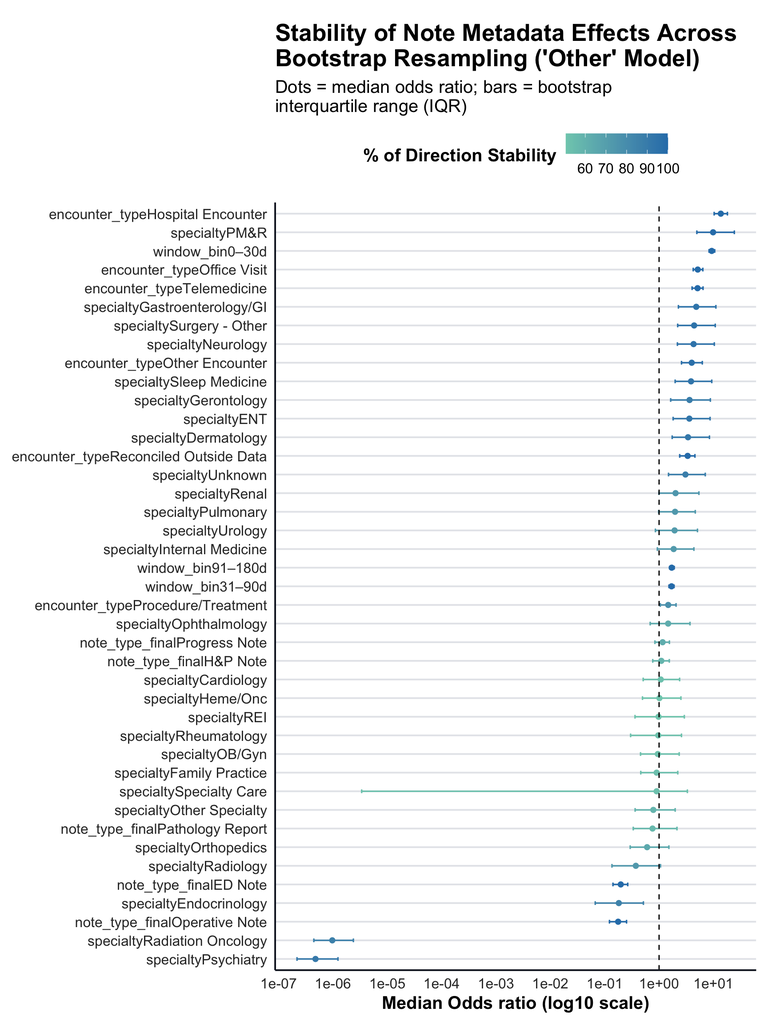

```r
# same code as clinical contraindications model and overall model to plot dot forest plot
summary_other_boot_results %>%
  filter(!term %in% c("specialtyPathology", "(Intercept)")) %>%
  mutate(term = fct_reorder(term, median_OR)) %>%
  ggplot(aes(x = term, y = median_OR, color = posneg_sign_pct)) +
  geom_errorbar(
    aes(ymin = IQR_low, ymax = IQR_high),
    width = 0.2,
    size  = 0.6
  ) +
  geom_point(size = 1.8) +
  geom_hline(yintercept = 1, linetype = "dashed") +
  scale_y_log10(breaks =scales::log_breaks(n = 10))  +
  coord_flip() +
  labs(
    x = NULL,
    y = "Median Odds ratio (log10 scale)",
    title = str_wrap(
      "Stability of Note Metadata Effects Across Bootstrap Resampling ('Other' Model)",
      width = 50),
    subtitle = str_wrap(
      "Dots = median odds ratio; bars = bootstrap interquartile range (IQR)",
      width = 50),
    color = "% of Direction Stability"
  ) +
  theme_osa(base_size = 15) +
  theme(
    axis.text.x = element_text(angle = 0, hjust = 0.5),
    axis.title.x = element_text(face = "bold"),
    plot.title = element_text(size = 20, face = "bold"),
    plot.margin = margin(t = 20, r = 10, b = 10, l = 10)
  ) +
  scale_color_gradientn(
    colors = c(
      "#7FCDBB",
      "#2C7FB8"
    )
  )
```

```r
# same code as from overall and clinical contraindications model to get count of term directional stability and randomness
summary_other_boot_results %>%
  filter(!term %in% c('(Intercept)', 'specialtyPathology')) %>%
  # terms with >= 90% directional stability
  filter(posneg_sign_pct >= 90.0) %>% summarize(count = n())
```

| count |
| --- |
| 18 |

```r
summary_other_boot_results %>%
  filter(!term %in% c('(Intercept)', 'specialtyPathology')) %>%
  # terms with <= 50% directional stability
  filter(posneg_sign_pct <= 50.0) %>% summarize(count = n())
```

| count |
| --- |
| 0 |

#### 4.3.4 Bootstrapping Interpretation

In summary, these bootstrapping results show that encounter type and time window are the most robust features across all of the models, whereas specialty and note type are more variable. Because of this, the effects of specialty and note type should be interpreted more cautiously.

| Category | Overall Exclusion Model | Clinical Contraindications Model | Other (Recent Procedures + Sleep Exclusions) Model |
| --- | --- | --- | --- |
| **Strongest Effect (Largest OR)** | Renal (specialty) OR = 19.5 | Hospital Encounter (encounte type) OR = 16.5 | 0–30 days (window bin) OR = 11.4 |
| **Most Statistically Significant (Lowest p-value)** | Office Visit (encounter type) p = 1.40 × 10⁻²⁵ | Office Visit (encounter type) p = 2.67 × 10⁻²⁴ | 0-30 days (window bin) p = 2.63 × 10⁻³⁷ |
| **Most Important Features Overall That Signal Exclusion** | `encounter_type` and temporal recency from pre-screening (`window_bin`) | `encounter_type` and `specialty` | `encounter_type` and temporal recency from pre-screening (`window_bin`) |

## 5 Conclusion

There were also several limitations. Although I manually spot-checked the reliability of LLM classification output, the note labels were not fully adjudicated by study coordinators or the clinical team. The cohort for this study was also small (164 patients and 2,911 notes) which may limit statistical power and increase uncertainty in the estimates. Finally, the results of this study may not be generalizable beyond this study population, sleep medicine, or even the Penn Medicine system.

Even with these limitations, the proposed workflow of using LLMs to extract exclusion signals and regression analysis of note metadata could be beneficial for clinical research recruitment in general. Specifically, this would provide greater transparency and standardization in the pre-screening process by exposing the informal patterns that CRCs rely on when deciding who to skip, which may then help define informal screening rules that could minimize recruitment bias.

For future directions, it will be important to validate the LLM output with CRC adjudication to determine whether the identified metadata predictors are plausible to the CRC. It will also be valuable to test whether the results from this project actually improve screening efficiency in practice.

## 6 References

Cai, T., Cai, F., Dahal, K. P., Cremone, G., Lam, E., Golnik, C., Seyok, T., Hong, C., Cai, T., & Liao, K. P. (2021). Improving the efficiency of clinical trial recruitment using an ensemble machine learning to assist with eligibility screening. *ACR Open Rheumatology, 3*(10), 593–600. https://doi.org/10.1002/acr2.11289

Etchberger, K. (2016, November 7). *Chart Review: Should Sponsors Pay for Clinical Research Sites to Review Charts?*. LinkedIn. https://www.linkedin.com/pulse/chart-review-should-sponsors-pay-clinical-research-sites-etchberger#:~:text=Some%20trials%20remain%20very%20complicated,takes%20to%20find%20those%20patients.

Lai, Y.S. & Afseth, J.D. (2019). A review of the impact of utilising electronic medical records for clinical research recruitment. *Clinical Trials, 16*(2):194-203. https://doi.org/10.1177/17407745198297

Motamedi, K. K., McClary, A. C., & Amedee, R. G. (2009). Obstructive sleep apnea: a growing problem. *Ochsner journal*, *9*(3), 149–153.

Norgeot, B., Muenzen, K., Peterson, T.A. et al. (2020). Protected Health Information filter (Philter): accurately and securely de-identifying free-text clinical notes. *npj Digit. Med. 3*:57. https://doi.org/10.1038/s41746-020-0258-y